# Analyse Growth And Present Insights To The Telangana Government

**About the project:**

- Telangana is one of the fastest-growing states in India and one of the states with an open data policy. (They have published all their data online)\
- Peter Pandey is an aspiring data analyst looking for a project with real-time data to add to his portfolio. He wanted to analyse Telangana’s growth among different sectors quantitatively and provide useful Insights to the Telangana government that would help them to make data-informed decisions that would further support the growth of the state\

Resource: https://codebasics.io/challenge/codebasics-resume-project-challenge

**Objective:**

- Explore the Stamp Registration, Transportation and Ts-Ipass Datasets.
- Analyze trends and patterns, categories and time period.
- Identify growth opportunities and areas needing attention.
- Find correlation among these departments and report the overall growth of the state through insights and relevant visuals such as shape maps.

**Audiences (Stackholders):**

- From Telangana Government
1. Kalvakuntla Taraka Rama Rao / KTR

Minister for IT, Industries and Municipal Administration: https://www.linkedin.com/in/ktramarao 2. Jayesh Ranjan Secretary, Information Technology (IT); Government of Telangana: https://www.linkedin.com/in/jayesh-ranjan-37415963 3. Dileep Konatham Director at Government of Telangana https://www.linkedin.com/in/dileep-konatham-2624b91b5 4. Venu Panjarla Open Data Telangana https://www.linkedin.com/in/venupanjarla

- From Codebasics Team
1. Dhaval Patel

Founder, Codebasics https://www.linkedin.com/in/dhavalsays/ 2. Hemanand Vadivel Co-Founder, Codebasics https://www.linkedin.com/in/hemvad/ codebasics.io

Use these hashtags so that we can track your work:\

# codebasicsresumeprojectchallenge #OpenDataTelangana #CRPC7\

Other Hashtags You Can Use\

# GovernmentofTelangana #HappeningHyderabad

**Primary Questions:**

- Stamp Registration
1. How does the revenue generated from document registration vary across districts in Telangana? List down the top 5 districts that showed the highest document registration revenue growth between FY 2019 and 2022.
2. How does the revenue generated from document registration compare to the revenue generated from e-stamp challans across districts? List down the top 5 districts where e-stamps revenue contributes significantly more to the revenue than the documents in FY 2022?
3. Is there any alteration of e-Stamp challan count and document registration count pattern since the implementation of e-Stamp challan? If so, what suggestions would you propose to the government?
4. Categorize districts into three segments based on their stamp registration revenue generation during the fiscal year 2021 to 2022.
- Transportation
5. Investigate whether there is any correlation between vehicle sales and specific months or seasons in different districts. Are there any months or seasons that consistently show higher or lower sales rate, and if yes, what could be the driving factors? (Consider Fuel-Type category only)
6. How does the distribution of vehicles vary by vehicle class (MotorCycle, MotorCar, AutoRickshaw, Agriculture) across different districts? Are there any districts with a predominant preference for a specific vehicle class? Consider FY 2022 for analysis.
7. List down the top 3 and bottom 3 districts that have shown the highest and lowest vehicle sales growth during FY 2022 compared to FY 2021? (Consider and compare categories: Petrol, Diesel and Electric)
- Ts-Ipass (Telangana State Industrial Project Approval and Self Certification System)
8. List down the top 5 sectors that have witnessed the most significant investments in FY 2022.
9. List down the top 3 districts that have attracted the most significant sector investments during FY 2019 to 2022? What factors could have led to the substantial investments in these particular districts?
10. Is there any relationship between district investments, vehicles sales and stamps revenue within the same district between FY 2021 and 2022?
11. Are there any particular sectors that have shown substantial investment in multiple districts between FY 2021 and 2022?
12. Can we identify any seasonal patterns or cyclicality in the investment trends for specific sectors? Do certain sectors experience higher investments during particular months?

**Author: Bao Thai**\

Linkedin: https://www.linkedin.com/in/bao-quoc-508008181/ \ Gmail: QuocBao363@gmail.com

## Import needed packages and libraries

```python
import numpy as np
import pandas as pd
import seaborn as sns
import matplotlib.pyplot as plt
```

## Import dataset

```python
dim_date = pd.read_csv("C:/Users/Admin/Desktop/Projects/TelanganaGrowthAnalysis/dataset/dim_date.csv")
date_data = dim_date.copy()
date_data.head()
```

|  | month | Mmm | quarter | fiscal_year |
| --- | --- | --- | --- | --- |
| 0 | 2019-04-01 | Apr | Q1 | 2019 |
| 1 | 2019-05-01 | May | Q1 | 2019 |
| 2 | 2019-06-01 | Jun | Q1 | 2019 |
| 3 | 2019-07-01 | Jul | Q2 | 2019 |
| 4 | 2019-08-01 | Aug | Q2 | 2019 |

```python
date_data.info()
```

```
<class 'pandas.core.frame.DataFrame'>
RangeIndex: 48 entries, 0 to 47
Data columns (total 4 columns):
 #   Column       Non-Null Count  Dtype
---  ------       --------------  -----
 0   month        48 non-null     object
 1   Mmm          48 non-null     object
 2   quarter      48 non-null     object
 3   fiscal_year  48 non-null     int64
dtypes: int64(1), object(3)
memory usage: 1.6+ KB
```

```python
date_data.isna().sum()
```

```
month          0
Mmm            0
quarter        0
fiscal_year    0
dtype: int64
```

```python
date_data.duplicated().sum()
```

```
0
```

```python
dim_districts = pd.read_csv("C:/Users/Admin/Desktop/Projects/TelanganaGrowthAnalysis/dataset/dim_districts.csv")
districts = dim_districts.copy()
districts.head()
```

|  | dist_code | district |
| --- | --- | --- |
| 0 | 19_1 | Adilabad |
| 1 | 22_2 | Bhadradri Kothagudem |
| 2 | 21_1 | Hanumakonda |
| 3 | 16_1 | Hyderabad |
| 4 | 20_2 | Jagtial |

```python
districts.info()
```

```
<class 'pandas.core.frame.DataFrame'>
RangeIndex: 33 entries, 0 to 32
Data columns (total 2 columns):
 #   Column     Non-Null Count  Dtype
---  ------     --------------  -----
 0   dist_code  33 non-null     object
 1   district   33 non-null     object
dtypes: object(2)
memory usage: 660.0+ bytes
```

```python
districts.isna().sum()
```

```
dist_code    0
district     0
dtype: int64
```

```python
districts.duplicated().sum()
```

```
0
```

```python
fact_stamps = pd.read_csv("C:/Users/Admin/Desktop/Projects/TelanganaGrowthAnalysis/dataset/fact_stamps.csv")
stamps = fact_stamps.copy()
stamps.head()
```

|  | dist_code | month | documents_registered_cnt | documents_registered_rev | estamps_challans_cnt | estamps_challans_rev |
| --- | --- | --- | --- | --- | --- | --- |
| 0 | 14_1 | 2019-04-01 | 4533 | 59236363 | 0 | 0 |
| 1 | 17_3 | 2019-04-01 | 4151 | 41508762 | 0 | 0 |
| 2 | 20_3 | 2019-04-01 | 2116 | 23674170 | 0 | 0 |
| 3 | 21_5 | 2019-04-01 | 1089 | 15915285 | 0 | 0 |
| 4 | 23_1 | 2019-04-01 | 6133 | 82593256 | 0 | 0 |

```python
stamps.info()
```

```
<class 'pandas.core.frame.DataFrame'>
RangeIndex: 1504 entries, 0 to 1503
Data columns (total 6 columns):
 #   Column                    Non-Null Count  Dtype
---  ------                    --------------  -----
 0   dist_code                 1504 non-null   object
 1   month                     1504 non-null   object
 2   documents_registered_cnt  1504 non-null   int64
 3   documents_registered_rev  1504 non-null   int64
 4   estamps_challans_cnt      1504 non-null   int64
 5   estamps_challans_rev      1504 non-null   int64
dtypes: int64(4), object(2)
memory usage: 70.6+ KB
```

```python
stamps.isna().sum()
```

```
dist_code                   0
month                       0
documents_registered_cnt    0
documents_registered_rev    0
estamps_challans_cnt        0
estamps_challans_rev        0
dtype: int64
```

```python
stamps.duplicated().sum()
```

```
0
```

```python
fact_TS_iPASS = pd.read_csv("C:/Users/Admin/Desktop/Projects/TelanganaGrowthAnalysis/dataset/fact_TS_iPASS.csv")
ts_ipass = fact_TS_iPASS.copy()
ts_ipass.head()
```

|  | dist_code | month | sector | investment in cr | number_of_employees |
| --- | --- | --- | --- | --- | --- |
| 0 | 14_1 | 01-04-2019 | Engineering | 2.3200 | 15 |
| 1 | 19_1 | 01-04-2019 | Engineering | 0.6250 | 13 |
| 2 | 20_3 | 01-04-2019 | Wood and Leather | 0.2000 | 8 |
| 3 | 20_3 | 01-04-2019 | Textiles | 0.2675 | 27 |
| 4 | 21_5 | 01-04-2019 | Electrical and Electronic Products | 0.1200 | 5 |

```python
ts_ipass.info()
```

```
<class 'pandas.core.frame.DataFrame'>
RangeIndex: 5753 entries, 0 to 5752
Data columns (total 5 columns):
 #   Column               Non-Null Count  Dtype
---  ------               --------------  -----
 0   dist_code            5753 non-null   object
 1   month                5753 non-null   object
 2   sector               5753 non-null   object
 3   investment in cr     5753 non-null   float64
 4   number_of_employees  5753 non-null   int64
dtypes: float64(1), int64(1), object(3)
memory usage: 224.9+ KB
```

```python
ts_ipass.isna().sum()
```

```
dist_code              0
month                  0
sector                 0
investment in cr       0
number_of_employees    0
dtype: int64
```

```python
ts_ipass.duplicated().sum()
```

```
0
```

```python
fact_transport = pd.read_csv("C:/Users/Admin/Desktop/Projects/TelanganaGrowthAnalysis/dataset/fact_transport.csv")
transport = fact_transport.copy()
transport.head()
```

|  | dist_code | month | fuel_type_petrol | fuel_type_diesel | fuel_type_electric | fuel_type_others | vehicleClass_MotorCycle | vehicleClass_MotorCar | vehicleClass_AutoRickshaw | vehicleClass_Agriculture | vehicleClass_others | seatCapacity_1_to_3 | seatCapacity_4_to_6 | seatCapacity_above_6 | Brand_new_vehicles | Pre-owned_vehicles | category_Non-Transport | category_Transport |
| --- | --- | --- | --- | --- | --- | --- | --- | --- | --- | --- | --- | --- | --- | --- | --- | --- | --- | --- |
| 0 | 15_1 | 2019-04-01 | 17910 | 3011 | 76 | 22 | 15308 | 4429 | 0 | 4 | 1278 | 16110 | 4182 | 717 | 19542 | 1477 | 19856 | 1163 |
| 1 | 18_2 | 2019-04-01 | 3066 | 306 | 6 | 0 | 2995 | 142 | 49 | 64 | 128 | 3156 | 189 | 33 | 3322 | 56 | 3203 | 175 |
| 2 | 20_3 | 2019-04-01 | 1577 | 215 | 0 | 0 | 1546 | 79 | 29 | 21 | 117 | 1683 | 104 | 5 | 1751 | 41 | 1648 | 144 |
| 3 | 21_3 | 2019-04-01 | 1961 | 281 | 2 | 0 | 1939 | 72 | 72 | 48 | 113 | 2082 | 146 | 16 | 2209 | 35 | 2075 | 169 |
| 4 | 21_7 | 2019-04-01 | 1552 | 309 | 0 | 0 | 1512 | 76 | 69 | 109 | 95 | 1696 | 145 | 20 | 1820 | 41 | 1701 | 160 |

```python
transport.info()
```

```
<class 'pandas.core.frame.DataFrame'>
RangeIndex: 1440 entries, 0 to 1439
Data columns (total 18 columns):
 #   Column                     Non-Null Count  Dtype
---  ------                     --------------  -----
 0   dist_code                  1440 non-null   object
 1   month                      1440 non-null   object
 2   fuel_type_petrol           1440 non-null   int64
 3   fuel_type_diesel           1440 non-null   int64
 4   fuel_type_electric         1440 non-null   int64
 5   fuel_type_others           1440 non-null   int64
 6   vehicleClass_MotorCycle    1440 non-null   int64
 7   vehicleClass_MotorCar      1440 non-null   int64
 8   vehicleClass_AutoRickshaw  1440 non-null   int64
 9   vehicleClass_Agriculture   1440 non-null   int64
 10  vehicleClass_others        1440 non-null   int64
 11  seatCapacity_1_to_3        1440 non-null   int64
 12  seatCapacity_4_to_6        1440 non-null   int64
 13  seatCapacity_above_6       1440 non-null   int64
 14  Brand_new_vehicles         1440 non-null   int64
 15  Pre-owned_vehicles         1440 non-null   int64
 16  category_Non-Transport     1440 non-null   int64
 17  category_Transport         1440 non-null   int64
dtypes: int64(16), object(2)
memory usage: 202.6+ KB
```

```python
transport.isna().sum()
```

```
dist_code                    0
month                        0
fuel_type_petrol             0
fuel_type_diesel             0
fuel_type_electric           0
fuel_type_others             0
vehicleClass_MotorCycle      0
vehicleClass_MotorCar        0
vehicleClass_AutoRickshaw    0
vehicleClass_Agriculture     0
vehicleClass_others          0
seatCapacity_1_to_3          0
seatCapacity_4_to_6          0
seatCapacity_above_6         0
Brand_new_vehicles           0
Pre-owned_vehicles           0
category_Non-Transport       0
category_Transport           0
dtype: int64
```

```python
transport.duplicated().sum()
```

```
0
```

## Merge dataset

### For analyzing about Stamp Registration

```python
stamps_df_temp = pd.merge(districts, stamps, on = 'dist_code', how = 'inner')
stamps_df_temp.head()
```

|  | dist_code | district | month | documents_registered_cnt | documents_registered_rev | estamps_challans_cnt | estamps_challans_rev |
| --- | --- | --- | --- | --- | --- | --- | --- |
| 0 | 19_1 | Adilabad | 2019-04-01 | 1043 | 12672655 | 0 | 0 |
| 1 | 19_1 | Adilabad | 2019-05-01 | 1092 | 15177385 | 0 | 0 |
| 2 | 19_1 | Adilabad | 2019-06-01 | 824 | 11443194 | 0 | 0 |
| 3 | 19_1 | Adilabad | 2019-07-01 | 1186 | 17853370 | 0 | 0 |
| 4 | 19_1 | Adilabad | 2019-08-01 | 1124 | 14955291 | 0 | 0 |

```python
stamps_df = pd.merge(date_data, stamps_df_temp, on = 'month', how = 'inner')
stamps_df.head()
```

|  | month | Mmm | quarter | fiscal_year | dist_code | district | documents_registered_cnt | documents_registered_rev | estamps_challans_cnt | estamps_challans_rev |
| --- | --- | --- | --- | --- | --- | --- | --- | --- | --- | --- |
| 0 | 2019-04-01 | Apr | Q1 | 2019 | 19_1 | Adilabad | 1043 | 12672655 | 0 | 0 |
| 1 | 2019-04-01 | Apr | Q1 | 2019 | 22_2 | Bhadradri Kothagudem | 542 | 12610700 | 0 | 0 |
| 2 | 2019-04-01 | Apr | Q1 | 2019 | 21_1 | Hanumakonda | 4186 | 120047007 | 0 | 0 |
| 3 | 2019-04-01 | Apr | Q1 | 2019 | 16_1 | Hyderabad | 5268 | 724238098 | 0 | 0 |
| 4 | 2019-04-01 | Apr | Q1 | 2019 | 20_2 | Jagtial | 1943 | 26031616 | 0 | 0 |

### For analyzing about Transportation

```python
transport_temp = pd.merge(districts, transport, on = 'dist_code' ,how = 'inner')
```

```python
transport_df = pd.merge(date_data, transport_temp, on = 'month', how = 'inner')
transport_df.head()
```

|  | month | Mmm | quarter | fiscal_year | dist_code | district | fuel_type_petrol | fuel_type_diesel | fuel_type_electric | fuel_type_others | ... | vehicleClass_AutoRickshaw | vehicleClass_Agriculture | vehicleClass_others | seatCapacity_1_to_3 | seatCapacity_4_to_6 | seatCapacity_above_6 | Brand_new_vehicles | Pre-owned_vehicles | category_Non-Transport | category_Transport |
| --- | --- | --- | --- | --- | --- | --- | --- | --- | --- | --- | --- | --- | --- | --- | --- | --- | --- | --- | --- | --- | --- |
| 0 | 2019-04-01 | Apr | Q1 | 2019 | 19_1 | Adilabad | 1758 | 326 | 0 | 2 | ... | 77 | 13 | 183 | 1823 | 184 | 79 | 2061 | 25 | 1832 | 254 |
| 1 | 2019-04-01 | Apr | Q1 | 2019 | 22_2 | Bhadradri Kothagudem | 3527 | 669 | 2 | 4 | ... | 231 | 74 | 254 | 3683 | 467 | 52 | 4096 | 106 | 3725 | 477 |
| 2 | 2019-04-01 | Apr | Q1 | 2019 | 16_1 | Hyderabad | 24309 | 2957 | 284 | 1540 | ... | 1518 | 0 | 1742 | 23082 | 5306 | 698 | 27121 | 1969 | 25973 | 3117 |
| 3 | 2019-04-01 | Apr | Q1 | 2019 | 20_2 | Jagtial | 2786 | 440 | 2 | 0 | ... | 106 | 121 | 146 | 2951 | 245 | 30 | 3120 | 108 | 2986 | 242 |
| 4 | 2019-04-01 | Apr | Q1 | 2019 | 21_3 | Jangoan | 1961 | 281 | 2 | 0 | ... | 72 | 48 | 113 | 2082 | 146 | 16 | 2209 | 35 | 2075 | 169 |

5 rows × 22 columns

### For analyzing about Ts Ipass

```python
ts_ipass_temp = pd.merge(districts, ts_ipass, on = 'dist_code', how = 'inner')
ts_ipass_temp
```

|  | dist_code | district | month | sector | investment in cr | number_of_employees |
| --- | --- | --- | --- | --- | --- | --- |
| 0 | 19_1 | Adilabad | 01-04-2019 | Engineering | 0.6250 | 13 |
| 1 | 19_1 | Adilabad | 01-04-2019 | Cement, Cement & Concrete Products, Fly Ash Br... | 19.3702 | 99 |
| 2 | 19_1 | Adilabad | 01-04-2019 | Food Processing | 0.0980 | 7 |
| 3 | 19_1 | Adilabad | 01-07-2019 | Beverages | 0.1300 | 3 |
| 4 | 19_1 | Adilabad | 01-07-2019 | Cement, Cement & Concrete Products, Fly Ash Br... | 0.7300 | 10 |
| ... | ... | ... | ... | ... | ... | ... |
| 5748 | 23_3 | Yadadri Bhuvanagiri | 01-03-2023 | Fertlizers Organic and Inorganic,Pesticides,In... | 1.2500 | 24 |
| 5749 | 23_3 | Yadadri Bhuvanagiri | 01-03-2023 | Food Processing | 15.4500 | 24 |
| 5750 | 23_3 | Yadadri Bhuvanagiri | 01-03-2023 | Pharmaceuticals and Chemicals | 1.2800 | 18 |
| 5751 | 23_3 | Yadadri Bhuvanagiri | 01-03-2023 | Plastic and Rubber | 0.4500 | 9 |
| 5752 | 23_3 | Yadadri Bhuvanagiri | 01-03-2023 | Textiles | 0.6629 | 13 |

5753 rows × 6 columns

```python
ts_ipass_temp['month'] = pd.to_datetime(ts_ipass_temp['month'], format='%d-%m-%Y').dt.strftime('%Y-%m-%d')
```

```python
ts_ipass_df = pd.merge(date_data, ts_ipass_temp, on = 'month', how = 'inner')
ts_ipass_df.head()
```

|  | month | Mmm | quarter | fiscal_year | dist_code | district | sector | investment in cr | number_of_employees |
| --- | --- | --- | --- | --- | --- | --- | --- | --- | --- |
| 0 | 2019-04-01 | Apr | Q1 | 2019 | 19_1 | Adilabad | Engineering | 0.6250 | 13 |
| 1 | 2019-04-01 | Apr | Q1 | 2019 | 19_1 | Adilabad | Cement, Cement & Concrete Products, Fly Ash Br... | 19.3702 | 99 |
| 2 | 2019-04-01 | Apr | Q1 | 2019 | 19_1 | Adilabad | Food Processing | 0.0980 | 7 |
| 3 | 2019-04-01 | Apr | Q1 | 2019 | 22_2 | Bhadradri Kothagudem | Paper and Printing | 0.2000 | 6 |
| 4 | 2019-04-01 | Apr | Q1 | 2019 | 22_2 | Bhadradri Kothagudem | Beverages | 0.0600 | 3 |

## Insight Analysis

### Stamp Registration

**1. How does the revenue generated from document registration vary across districts in Telangana? List down the top 5 districts that showed the highest document registration revenue growth between FY 2019 and 2022.**

```python
revenue = stamps_df[stamps_df['fiscal_year'].isin([2019, 2022])].groupby(['district','fiscal_year'])['documents_registered_rev'].sum().unstack()
revenue['growth'] = ((revenue[2022] - revenue[2019])/revenue[2019])
revenue['growth'].sort_values(ascending = False)
top5_growth_districts = revenue.head(5)
top5_growth_districts
```

| fiscal_year district | 2019 | 2022 | growth |
| --- | --- | --- | --- |
| Adilabad | 178082233 | 396840845 | 1.228413 |
| Bhadradri Kothagudem | 162466947 | 292643450 | 0.801249 |
| Hanumakonda | 1738280378 | 2817238587 | 0.620704 |
| Hyderabad | 8299406278 | 14266012441 | 0.718920 |
| Jagtial | 357209544 | 628898536 | 0.760587 |

```python
top5_revenue_districts = top5_growth_districts.reset_index().melt(id_vars = 'district', value_vars = [2019,2022], var_name = 'year', value_name = 'revenue')
top5_revenue_districts
```

|  | district | year | revenue |
| --- | --- | --- | --- |
| 0 | Adilabad | 2019 | 178082233 |
| 1 | Bhadradri Kothagudem | 2019 | 162466947 |
| 2 | Hanumakonda | 2019 | 1738280378 |
| 3 | Hyderabad | 2019 | 8299406278 |
| 4 | Jagtial | 2019 | 357209544 |
| 5 | Adilabad | 2022 | 396840845 |
| 6 | Bhadradri Kothagudem | 2022 | 292643450 |
| 7 | Hanumakonda | 2022 | 2817238587 |
| 8 | Hyderabad | 2022 | 14266012441 |
| 9 | Jagtial | 2022 | 628898536 |

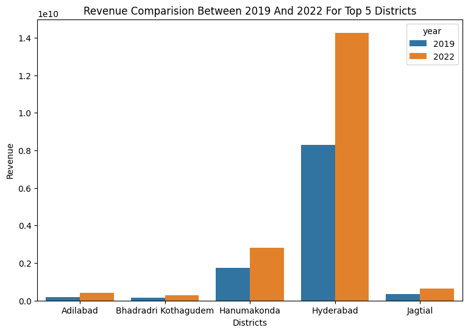

```python
plt.figure(figsize = (9,6))
sns.barplot(x= top5_revenue_districts['district'], y = top5_revenue_districts['revenue'], hue = top5_revenue_districts['year'])
plt.title('Revenue Comparision Between 2019 And 2022 For Top 5 Districts')
plt.xlabel('Districts')
plt.ylabel('Revenue')
plt.show()
```

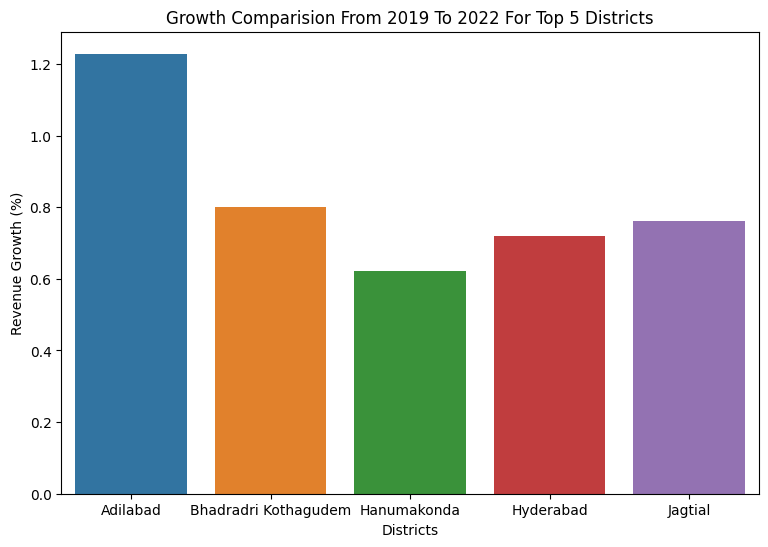

```python
plt.figure(figsize = (9,6))
sns.barplot(x= top5_growth_districts.index, y = top5_growth_districts['growth'])
plt.title('Growth Comparision From 2019 To 2022 For Top 5 Districts')
plt.xlabel('Districts')
plt.ylabel('Revenue Growth (%)')
plt.show()
```

**2. How does the revenue generated from document registration compare to the revenue generated from e-stamp challans across districts? List down the top 5 districts where e-stamps revenue contributes significantly more to the revenue than the documents in FY 2022?**

```python
rev_stamp_doc_2022 = stamps_df[stamps_df['fiscal_year'].isin([2022])].groupby(stamps_df['district'])[['documents_registered_rev','estamps_challans_rev']].sum()
rev_stamp_doc_2022 = rev_stamp_doc_2022.reset_index()
rev_stamp_doc_2022['different_revenue'] = rev_stamp_doc_2022['estamps_challans_rev'] -  rev_stamp_doc_2022['documents_registered_rev']
rev_stamp_doc_2022 = rev_stamp_doc_2022.sort_values(by = 'different_revenue', ascending = False)
top5_diff_rev_2022 = rev_stamp_doc_2022.head(5)
top5_diff_rev_2022
```

|  | district | documents_registered_rev | estamps_challans_rev | different_revenue |
| --- | --- | --- | --- | --- |
| 24 | Rangareddy | 37697750946 | 38349357618 | 651606672 |
| 3 | Hyderabad | 14266012441 | 14374315032 | 108302591 |
| 9 | Khammam | 1971647539 | 2002220314 | 30572775 |
| 2 | Hanumakonda | 2817238587 | 2846856844 | 29618257 |
| 31 | Yadadri Bhuvanagiri | 2167480603 | 2185270667 | 17790064 |

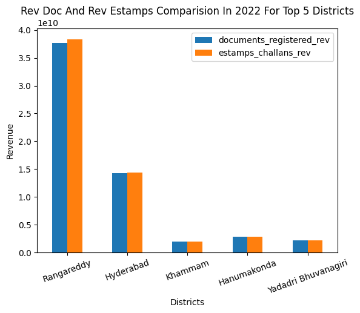

```python
plt.figure(figsize = (9,6))
top5_diff_rev_2022.plot(x = 'district', y = ['documents_registered_rev','estamps_challans_rev'], kind = 'bar')
plt.title('Rev Doc And Rev Estamps Comparision In 2022 For Top 5 Districts')
plt.xlabel('Districts')
plt.ylabel('Revenue')
plt.xticks(rotation = 20)
plt.show()
```

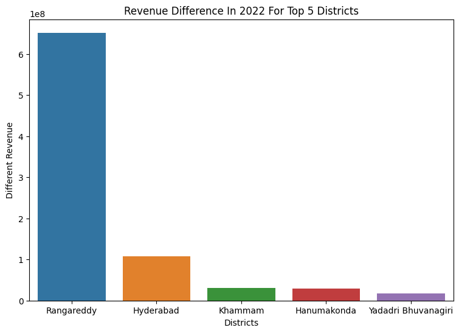

```python
plt.figure(figsize = (9,6))
sns.barplot(x = top5_diff_rev_2022['district'], y = top5_diff_rev_2022['different_revenue'])
plt.title('Revenue Difference In 2022 For Top 5 Districts')
plt.xlabel('Districts')
plt.ylabel('Different Revenue')
plt.show()
```

1. **Rangareddy**: The revenue from documents registered was **37,697,750,946**, while the revenue from e-stamps challans was **38,349,357,618**. The difference in revenue is **651,606,672**.
2. **Hyderabad**: The revenue from documents registered was **14,266,012,441**, while the revenue from e-stamps challans was **14,374,315,032**. The difference in revenue is **108,302,591**.
3. **Khammam**: The revenue from documents registered was **1,971,647,539**, while the revenue from e-stamps challans was **2,002,220,314**. The difference in revenue is **30,572,775**.
4. **Hanumakonda**: The revenue from documents registered was **2,817,238,587**, while the revenue from e-stamps challans was **2,846,856,844**. The difference in revenue is **29,618,257**.
5. **Yadadri Bhuvanagiri**: The revenue from documents registered was **2,167,480,603**, while the revenue from e-stamps challans was **2,185,270,667**. The difference in revenue is **17,790,064**.

**3. Is there any alteration of e-Stamp challan count and document registration count pattern since the implementation of e-Stamp challan? If so, what suggestions would you propose to the government?**

```python
estamps_yearly = stamps_df.groupby(stamps_df['fiscal_year'])[['estamps_challans_cnt','estamps_challans_rev']].sum()
estamps_yearly = estamps_yearly.reset_index()
estamps_yearly
```

|  | fiscal_year | estamps_challans_cnt | estamps_challans_rev |
| --- | --- | --- | --- |
| 0 | 2019 | 0 | 0 |
| 1 | 2020 | 496132 | 27866550225 |
| 2 | 2021 | 1173978 | 85665322428 |
| 3 | 2022 | 1254961 | 107149881605 |

```python
documents_registered_yearly = stamps_df.groupby(stamps_df['fiscal_year'])[['documents_registered_cnt','documents_registered_rev']].sum()
documents_registered_yearly = documents_registered_yearly.reset_index()
documents_registered_yearly
```

|  | fiscal_year | documents_registered_cnt | documents_registered_rev |
| --- | --- | --- | --- |
| 0 | 2019 | 1614417 | 62410774226 |
| 1 | 2020 | 943893 | 42047114334 |
| 2 | 2021 | 1104580 | 84075980256 |
| 3 | 2022 | 1207073 | 106695404941 |

```python
comparison = pd.merge(estamps_yearly, documents_registered_yearly, on = 'fiscal_year', how = 'inner')
comparison
```

|  | fiscal_year | estamps_challans_cnt | estamps_challans_rev | documents_registered_cnt | documents_registered_rev |
| --- | --- | --- | --- | --- | --- |
| 0 | 2019 | 0 | 0 | 1614417 | 62410774226 |
| 1 | 2020 | 496132 | 27866550225 | 943893 | 42047114334 |
| 2 | 2021 | 1173978 | 85665322428 | 1104580 | 84075980256 |
| 3 | 2022 | 1254961 | 107149881605 | 1207073 | 106695404941 |

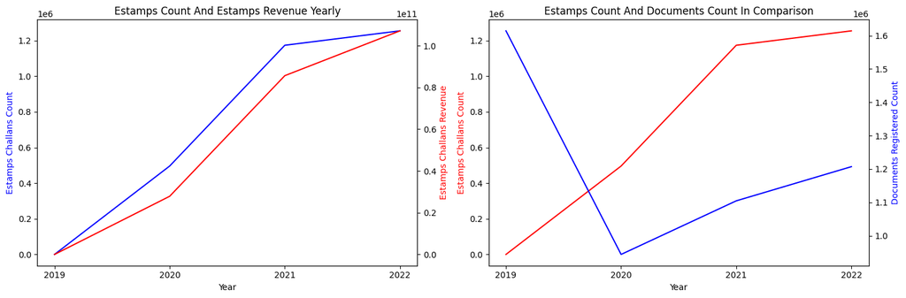

```python
fig, (ax1, ax3) = plt.subplots(1,2, figsize=(15,5))

#Estamps Challan count and Estamps Challan revenue
ax2 = ax1.twinx()
ax1.plot(estamps_yearly['fiscal_year'], estamps_yearly['estamps_challans_cnt'], color='blue')
ax2.plot(estamps_yearly['fiscal_year'], estamps_yearly['estamps_challans_rev'], color='red')

#Estamps Challan cound and Document count in comparison
ax4 = ax3.twinx()
ax3.plot(comparison['fiscal_year'], comparison['estamps_challans_cnt'], color = 'red')
ax4.plot(comparison['fiscal_year'], comparison['documents_registered_cnt'], color = 'blue')

#Title for plots
ax1.set_title('Estamps Count And Estamps Revenue Yearly')
ax1.set_xlabel('Year')
ax1.set_ylabel('Estamps Challans Count', color='blue')
ax2.set_ylabel('Estamps Challans Revenue', color='red')
ax1.set_xticks(estamps_yearly['fiscal_year'].unique())

ax3.set_title('Estamps Count And Documents Count In Comparison')
ax3.set_xlabel('Year')
ax3.set_ylabel('Estamps Challans Count', color = 'red')
ax4.set_ylabel('Documents Registered Count', color = 'blue')
ax3.set_xticks(comparison['fiscal_year'].unique())

plt.tight_layout()
plt.show()
```

**From the charts above we can see that since the implementation of e-Stamp challan in 2020:**

- The count of e-Stamp challans has been increasing year by year.
- The revenue from e-Stamp challans has also been increasing significantly.
- The count of documents registered decreased in 2020 compared to 2019 but started increasing again in the following years.
- The revenue from documents registered also shows a similar pattern.

**Based on these observations:**

- It seems that the implementation of e-Stamp challan has been successful and well-received as indicated by the increasing counts and revenues.
- However, it’s important to ensure that document registration does not decrease as it’s also a significant source of revenue.

**As for suggestions to the government:**

- Promote Awareness: Continue to promote awareness about the benefits and convenience of e-Stamp challans to encourage more people to use this service.
- Improve Accessibility: Ensure that the process of obtaining e-Stamp challans is easy and accessible to everyone across all districts.
- Monitor Trends: Keep monitoring the trends in both e-Stamp challan and document registration counts and revenues to identify any potential issues or opportunities for improvement.
- Maintain Balance: While promoting e-Stamp challans, also ensure that document registration services are not neglected. Both services are important and contribute significantly to the revenue

**4. Categorize districts into three segments based on their stamp registration revenue generation during the fiscal year 2021 to 2022.**

```python
stamps_df_2021_2022 = stamps_df[stamps_df['fiscal_year'].isin([2021,2022])]
stamps_df_2021_2022['estamps_challans_rev'].describe()
```

```
count    7.360000e+02
mean     2.619772e+08
std      6.474970e+08
min      7.237980e+05
25%      2.633567e+07
50%      4.749806e+07
75%      1.221248e+08
max      4.294273e+09
Name: estamps_challans_rev, dtype: float64
```

```python
q1 = stamps_df_2021_2022['estamps_challans_rev'].quantile(0.25)
q2 = stamps_df_2021_2022['estamps_challans_rev'].quantile(0.50)
q3 = stamps_df_2021_2022['estamps_challans_rev'].quantile(0.75)
```

```python
stamps_df_2021_2022['segment'] = pd.cut(stamps_df_2021_2022['estamps_challans_rev'], [0, q1, q3, float('inf')], labels=['Low', 'Medium', 'High'])
segment_counts = stamps_df_2021_2022['segment'].value_counts()
segment_counts
```

```
Medium    368
Low       184
High      184
Name: segment, dtype: int64
```

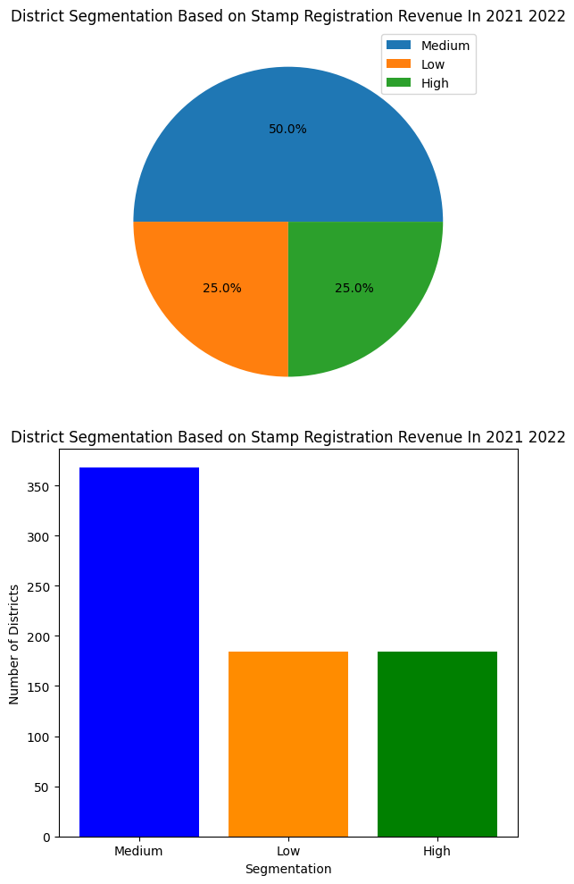

```python
fig, ax = plt.subplots(2,1, figsize = (6,10))

ax[0].pie(segment_counts, autopct='%1.1f%%')
ax[0].set_title('District Segmentation Based on Stamp Registration Revenue In 2021 2022')
ax[0].legend(labels = segment_counts.index)

ax[1].bar(segment_counts.index, segment_counts.values, color = ['blue', 'darkorange','green'])
ax[1].set_title('District Segmentation Based on Stamp Registration Revenue In 2021 2022')
ax[1].set_xlabel('Segmentation')
ax[1].set_ylabel('Number of Districts')

plt.tight_layout()
plt.show()
```

### Transportation

**5. Investigate whether there is any correlation between vehicle sales and specific months or seasons in different districts. Are there any months or seasons that consistently show higher or lower sales rate, and if yes, what could be the driving factors? (Consider Fuel-Type category only)**

- Analyzing total sales Fuel-Typed in 2019:

```python
grouped_2019_by_quar_month = transport_df[transport_df['fiscal_year'] == 2019].groupby(['quarter','Mmm']).sum()
grouped_2019_by_quar_month['total_sales_fuel_typed'] = (
     grouped_2019_by_quar_month['fuel_type_petrol'] +
     grouped_2019_by_quar_month['fuel_type_diesel'] +
     grouped_2019_by_quar_month['fuel_type_electric'] +
     grouped_2019_by_quar_month['fuel_type_others'])
grouped_2019_by_quar_month = grouped_2019_by_quar_month.reset_index()
grouped_2019_by_quar_month.head()
```

|  | quarter | Mmm | fiscal_year | fuel_type_petrol | fuel_type_diesel | fuel_type_electric | fuel_type_others | vehicleClass_MotorCycle | vehicleClass_MotorCar | vehicleClass_AutoRickshaw | vehicleClass_Agriculture | vehicleClass_others | seatCapacity_1_to_3 | seatCapacity_4_to_6 | seatCapacity_above_6 | Brand_new_vehicles | Pre-owned_vehicles | category_Non-Transport | category_Transport | total_sales_fuel_typed |
| --- | --- | --- | --- | --- | --- | --- | --- | --- | --- | --- | --- | --- | --- | --- | --- | --- | --- | --- | --- | --- |
| 0 | Q1 | Apr | 60570 | 140694 | 23098 | 477 | 1742 | 131322 | 17868 | 4821 | 1997 | 10003 | 140624 | 22048 | 3296 | 158951 | 7060 | 151922 | 14089 | 166011 |
| 1 | Q1 | Jun | 60570 | 141494 | 29331 | 328 | 1967 | 131213 | 18434 | 5795 | 4112 | 13566 | 144697 | 23320 | 4873 | 165108 | 8012 | 154501 | 18619 | 173120 |
| 2 | Q1 | May | 60570 | 143436 | 25605 | 287 | 1998 | 132566 | 18914 | 5054 | 2784 | 12008 | 143843 | 23211 | 4181 | 163618 | 7708 | 155076 | 16250 | 171326 |
| 3 | Q2 | Aug | 60570 | 126787 | 23525 | 256 | 2783 | 116938 | 17768 | 6792 | 1281 | 10572 | 125607 | 24175 | 3516 | 145140 | 8211 | 136555 | 16796 | 153351 |
| 4 | Q2 | Jul | 60570 | 131449 | 23550 | 383 | 2717 | 123110 | 15159 | 6740 | 2158 | 10930 | 132811 | 21907 | 3282 | 149925 | 8174 | 141025 | 17074 | 158099 |

```python
pivot_2019_by_month = pd.pivot_table(grouped_2019_by_quar_month, index = 'Mmm', values = 'total_sales_fuel_typed')
pivot_2019_by_month = pivot_2019_by_month.reset_index()
```

```python
months_order = ['Jan', 'Feb', 'Mar', 'Apr', 'May', 'Jun', 'Jul', 'Aug', 'Sep', 'Oct', 'Nov', 'Dec']
pivot_2019_by_month['Mmm'] = pd.Categorical(pivot_2019_by_month['Mmm'], categories=months_order, ordered=True)
pivot_2019_by_month = pivot_2019_by_month.sort_values('Mmm')
pivot_2019_by_month
```

|  | Mmm | total_sales_fuel_typed |
| --- | --- | --- |
| 4 | Jan | 162447 |
| 3 | Feb | 184469 |
| 7 | Mar | 155629 |
| 0 | Apr | 166011 |
| 8 | May | 171326 |
| 6 | Jun | 173120 |
| 5 | Jul | 158099 |
| 1 | Aug | 153351 |
| 11 | Sep | 123221 |
| 10 | Oct | 261064 |
| 9 | Nov | 180614 |
| 2 | Dec | 154220 |

```python
pivot_2019_by_quar = pd.pivot_table(grouped_2019_by_quar_month, index = 'quarter', values = 'total_sales_fuel_typed')
pivot_2019_by_quar = pivot_2019_by_quar.reset_index()
pivot_2019_by_quar
```

|  | quarter | total_sales_fuel_typed |
| --- | --- | --- |
| 0 | Q1 | 170152.333333 |
| 1 | Q2 | 144890.333333 |
| 2 | Q3 | 198632.666667 |
| 3 | Q4 | 167515.000000 |

- Analyzing total sales Fuel-Typed in 2020:

```python
grouped_2020_by_quar_month = transport_df[transport_df['fiscal_year'] == 2020].groupby(['quarter','Mmm']).sum()
grouped_2020_by_quar_month['total_sales_fuel_typed'] = (
     grouped_2020_by_quar_month['fuel_type_petrol'] +
     grouped_2020_by_quar_month['fuel_type_diesel'] +
     grouped_2020_by_quar_month['fuel_type_electric'] +
     grouped_2020_by_quar_month['fuel_type_others'])
grouped_2020_by_quar_month = grouped_2020_by_quar_month.reset_index()
grouped_2020_by_quar_month.head()
```

|  | quarter | Mmm | fiscal_year | fuel_type_petrol | fuel_type_diesel | fuel_type_electric | fuel_type_others | vehicleClass_MotorCycle | vehicleClass_MotorCar | vehicleClass_AutoRickshaw | vehicleClass_Agriculture | vehicleClass_others | seatCapacity_1_to_3 | seatCapacity_4_to_6 | seatCapacity_above_6 | Brand_new_vehicles | Pre-owned_vehicles | category_Non-Transport | category_Transport | total_sales_fuel_typed |
| --- | --- | --- | --- | --- | --- | --- | --- | --- | --- | --- | --- | --- | --- | --- | --- | --- | --- | --- | --- | --- |
| 0 | Q1 | Apr | 60600 | 341 | 1652 | 0 | 1 | 337 | 6 | 3 | 952 | 696 | 1981 | 9 | 4 | 1980 | 14 | 1332 | 662 | 1994 |
| 1 | Q1 | Jun | 60600 | 140052 | 18478 | 177 | 137 | 127355 | 15406 | 868 | 7628 | 7587 | 141939 | 15153 | 1752 | 151995 | 6849 | 150848 | 7996 | 158844 |
| 2 | Q1 | May | 60600 | 58963 | 9491 | 50 | 62 | 54769 | 4848 | 248 | 4809 | 3892 | 63266 | 4722 | 578 | 66335 | 2231 | 64677 | 3889 | 68566 |
| 3 | Q2 | Aug | 60600 | 124697 | 13220 | 240 | 239 | 108038 | 19577 | 561 | 3441 | 6779 | 117615 | 18516 | 2253 | 130997 | 7399 | 131690 | 6706 | 138396 |
| 4 | Q2 | Jul | 60600 | 119936 | 16687 | 253 | 205 | 105946 | 16946 | 764 | 5357 | 8068 | 118730 | 16319 | 2030 | 130381 | 6700 | 128991 | 8090 | 137081 |

```python
pivot_2020_by_month = pd.pivot_table(grouped_2020_by_quar_month, index = 'Mmm', values = 'total_sales_fuel_typed')
pivot_2020_by_month = pivot_2020_by_month.reset_index()
```

```python
months_order = ['Jan', 'Feb', 'Mar', 'Apr', 'May', 'Jun', 'Jul', 'Aug', 'Sep', 'Oct', 'Nov', 'Dec']
pivot_2020_by_month['Mmm'] = pd.Categorical(pivot_2020_by_month['Mmm'], categories=months_order, ordered=True)
pivot_2020_by_month = pivot_2020_by_month.sort_values('Mmm')
pivot_2020_by_month
```

|  | Mmm | total_sales_fuel_typed |
| --- | --- | --- |
| 4 | Jan | 158645 |
| 3 | Feb | 152989 |
| 7 | Mar | 155028 |
| 0 | Apr | 1994 |
| 8 | May | 68566 |
| 6 | Jun | 158844 |
| 5 | Jul | 137081 |
| 1 | Aug | 138396 |
| 11 | Sep | 139619 |
| 10 | Oct | 203828 |
| 9 | Nov | 190147 |
| 2 | Dec | 153072 |

```python
pivot_2020_by_quar = pd.pivot_table(grouped_2020_by_quar_month, index = 'quarter', values = 'total_sales_fuel_typed')
pivot_2020_by_quar = pivot_2020_by_quar.reset_index()
pivot_2020_by_quar
```

|  | quarter | total_sales_fuel_typed |
| --- | --- | --- |
| 0 | Q1 | 76468.000000 |
| 1 | Q2 | 138365.333333 |
| 2 | Q3 | 182349.000000 |
| 3 | Q4 | 155554.000000 |

- Analyzing total sales Fuel-Typed in 2021:

```python
grouped_2021_by_quar_month = transport_df[transport_df['fiscal_year'] == 2021].groupby(['quarter','Mmm']).sum()
grouped_2021_by_quar_month['total_sales_fuel_typed'] = (
     grouped_2021_by_quar_month['fuel_type_petrol'] +
     grouped_2021_by_quar_month['fuel_type_diesel'] +
     grouped_2021_by_quar_month['fuel_type_electric'] +
     grouped_2021_by_quar_month['fuel_type_others'])
grouped_2021_by_quar_month = grouped_2021_by_quar_month.reset_index()
grouped_2021_by_quar_month.head()
```

|  | quarter | Mmm | fiscal_year | fuel_type_petrol | fuel_type_diesel | fuel_type_electric | fuel_type_others | vehicleClass_MotorCycle | vehicleClass_MotorCar | vehicleClass_AutoRickshaw | vehicleClass_Agriculture | vehicleClass_others | seatCapacity_1_to_3 | seatCapacity_4_to_6 | seatCapacity_above_6 | Brand_new_vehicles | Pre-owned_vehicles | category_Non-Transport | category_Transport | total_sales_fuel_typed |
| --- | --- | --- | --- | --- | --- | --- | --- | --- | --- | --- | --- | --- | --- | --- | --- | --- | --- | --- | --- | --- |
| 0 | Q1 | Apr | 60630 | 107965 | 17006 | 938 | 845 | 88954 | 24216 | 1066 | 4482 | 8036 | 100413 | 23601 | 2736 | 118576 | 8178 | 118095 | 8659 | 126754 |
| 1 | Q1 | Jun | 60630 | 113917 | 21934 | 1336 | 422 | 97573 | 21029 | 479 | 9593 | 8935 | 115255 | 20001 | 2351 | 129332 | 8277 | 128499 | 9110 | 137609 |
| 2 | Q1 | May | 60630 | 57942 | 10888 | 351 | 284 | 47877 | 13185 | 199 | 4021 | 4183 | 55557 | 12710 | 1196 | 65067 | 4398 | 65287 | 4178 | 69465 |
| 3 | Q2 | Aug | 60630 | 118016 | 16013 | 1970 | 1538 | 96739 | 28710 | 1481 | 3083 | 7528 | 106498 | 27539 | 3498 | 127472 | 10069 | 128989 | 8552 | 137537 |
| 4 | Q2 | Jul | 60630 | 117253 | 19452 | 1931 | 1205 | 97707 | 26240 | 1051 | 5561 | 9282 | 111278 | 24944 | 3612 | 130057 | 9784 | 129944 | 9897 | 139841 |

```python
pivot_2021_by_month = pd.pivot_table(grouped_2021_by_quar_month, index = 'Mmm', values = 'total_sales_fuel_typed')
pivot_2021_by_month = pivot_2021_by_month.reset_index()
```

```python
months_order = ['Jan', 'Feb', 'Mar', 'Apr', 'May', 'Jun', 'Jul', 'Aug', 'Sep', 'Oct', 'Nov', 'Dec']
pivot_2021_by_month['Mmm'] = pd.Categorical(pivot_2021_by_month['Mmm'], categories=months_order, ordered=True)
pivot_2021_by_month = pivot_2021_by_month.sort_values('Mmm')
pivot_2021_by_month
```

|  | Mmm | total_sales_fuel_typed |
| --- | --- | --- |
| 4 | Jan | 115575 |
| 3 | Feb | 131554 |
| 7 | Mar | 138385 |
| 0 | Apr | 126754 |
| 8 | May | 69465 |
| 6 | Jun | 137609 |
| 5 | Jul | 139841 |
| 1 | Aug | 137537 |
| 11 | Sep | 109592 |
| 10 | Oct | 173020 |
| 9 | Nov | 143488 |
| 2 | Dec | 127485 |

```python
pivot_2021_by_quar = pd.pivot_table(grouped_2021_by_quar_month, index = 'quarter', values = 'total_sales_fuel_typed')
pivot_2021_by_quar = pivot_2021_by_quar.reset_index()
pivot_2021_by_quar
```

|  | quarter | total_sales_fuel_typed |
| --- | --- | --- |
| 0 | Q1 | 111276.000000 |
| 1 | Q2 | 128990.000000 |
| 2 | Q3 | 147997.666667 |
| 3 | Q4 | 128504.666667 |

- Analyzing total sales Fuel-Typed in 2022:

```python
grouped_2022_by_quar_month = transport_df[transport_df['fiscal_year'] == 2022].groupby(['quarter','Mmm']).sum()
grouped_2022_by_quar_month['total_sales_fuel_typed'] = (
     grouped_2022_by_quar_month['fuel_type_petrol'] +
     grouped_2022_by_quar_month['fuel_type_diesel'] +
     grouped_2022_by_quar_month['fuel_type_electric'] +
     grouped_2022_by_quar_month['fuel_type_others'])
grouped_2022_by_quar_month = grouped_2022_by_quar_month.reset_index()
grouped_2022_by_quar_month.head()
```

|  | quarter | Mmm | fiscal_year | fuel_type_petrol | fuel_type_diesel | fuel_type_electric | fuel_type_others | vehicleClass_MotorCycle | vehicleClass_MotorCar | vehicleClass_AutoRickshaw | vehicleClass_Agriculture | vehicleClass_others | seatCapacity_1_to_3 | seatCapacity_4_to_6 | seatCapacity_above_6 | Brand_new_vehicles | Pre-owned_vehicles | category_Non-Transport | category_Transport | total_sales_fuel_typed |
| --- | --- | --- | --- | --- | --- | --- | --- | --- | --- | --- | --- | --- | --- | --- | --- | --- | --- | --- | --- | --- |
| 0 | Q1 | Apr | 60660 | 109884 | 17983 | 5712 | 2385 | 95782 | 25142 | 1697 | 2417 | 10934 | 107353 | 24780 | 3803 | 125111 | 10861 | 123883 | 12089 | 135964 |
| 1 | Q1 | Jun | 60660 | 113121 | 23838 | 3956 | 2926 | 94599 | 26659 | 2137 | 5487 | 14961 | 110832 | 27237 | 5603 | 130625 | 13218 | 127259 | 16584 | 143841 |
| 2 | Q1 | May | 60660 | 104266 | 19572 | 3696 | 2304 | 86691 | 24642 | 1799 | 3702 | 13008 | 100677 | 24608 | 4443 | 119272 | 10570 | 115491 | 14351 | 129838 |
| 3 | Q2 | Aug | 60660 | 112693 | 16524 | 6711 | 3839 | 95882 | 28016 | 2952 | 1958 | 10969 | 105162 | 29706 | 4710 | 125355 | 14422 | 126238 | 13539 | 139767 |
| 4 | Q2 | Jul | 60660 | 97171 | 19582 | 4425 | 2793 | 80980 | 25062 | 2086 | 3326 | 12517 | 93294 | 25614 | 4795 | 111350 | 12621 | 109736 | 14235 | 123971 |

```python
pivot_2022_by_month = pd.pivot_table(grouped_2022_by_quar_month, index = 'Mmm', values = 'total_sales_fuel_typed')
pivot_2022_by_month = pivot_2022_by_month.reset_index()
pivot_2022_by_month
```

|  | Mmm | total_sales_fuel_typed |
| --- | --- | --- |
| 0 | Apr | 135964 |
| 1 | Aug | 139767 |
| 2 | Dec | 73214 |
| 3 | Feb | 66431 |
| 4 | Jan | 127824 |
| 5 | Jul | 123971 |
| 6 | Jun | 143841 |
| 7 | Mar | 151416 |
| 8 | May | 129838 |
| 9 | Nov | 72127 |
| 10 | Oct | 110900 |
| 11 | Sep | 138399 |

```python
months_order = ['Jan', 'Feb', 'Mar', 'Apr', 'May', 'Jun', 'Jul', 'Aug', 'Sep', 'Oct', 'Nov', 'Dec']
pivot_2022_by_month['Mmm'] = pd.Categorical(pivot_2022_by_month['Mmm'], categories=months_order, ordered=True)
pivot_2022_by_month = pivot_2022_by_month.sort_values('Mmm')
```

```python
pivot_2022_by_quar = pd.pivot_table(grouped_2022_by_quar_month, index = 'quarter', values = 'total_sales_fuel_typed')
pivot_2022_by_quar = pivot_2022_by_quar.reset_index()
pivot_2022_by_quar
```

|  | quarter | total_sales_fuel_typed |
| --- | --- | --- |
| 0 | Q1 | 136547.666667 |
| 1 | Q2 | 134045.666667 |
| 2 | Q3 | 85413.666667 |
| 3 | Q4 | 115223.666667 |

- Analyzing total sales Fuel-Typed yearly:

```python
grouped_by_yearly = transport_df.groupby(['fiscal_year']).sum()
grouped_by_yearly['total_sales_fuel_typed'] = (
     grouped_by_yearly['fuel_type_petrol'] +
     grouped_by_yearly['fuel_type_diesel'] +
     grouped_by_yearly['fuel_type_electric'] +
    grouped_by_yearly['fuel_type_others'])
grouped_by_yearly = grouped_by_yearly.reset_index()
grouped_by_yearly.head()
```

|  | fiscal_year | fuel_type_petrol | fuel_type_diesel | fuel_type_electric | fuel_type_others | vehicleClass_MotorCycle | vehicleClass_MotorCar | vehicleClass_AutoRickshaw | vehicleClass_Agriculture | vehicleClass_others | seatCapacity_1_to_3 | seatCapacity_4_to_6 | seatCapacity_above_6 | Brand_new_vehicles | Pre-owned_vehicles | category_Non-Transport | category_Transport | total_sales_fuel_typed |
| --- | --- | --- | --- | --- | --- | --- | --- | --- | --- | --- | --- | --- | --- | --- | --- | --- | --- | --- |
| 0 | 2019 | 1669884 | 341790 | 4143 | 27754 | 1524671 | 233632 | 75003 | 45797 | 164462 | 1695324 | 304299 | 43088 | 1936747 | 106824 | 1811731 | 231840 | 2043571 |
| 1 | 2020 | 1433801 | 212145 | 5980 | 6283 | 1232661 | 246120 | 11919 | 64991 | 102580 | 1391270 | 239278 | 27627 | 1566049 | 92228 | 1551106 | 107171 | 1658209 |
| 2 | 2021 | 1300723 | 199346 | 31004 | 19232 | 1097546 | 288537 | 17524 | 49754 | 96951 | 1231864 | 280517 | 37757 | 1440068 | 110249 | 1441048 | 109269 | 1550305 |
| 3 | 2022 | 1118857 | 196103 | 62532 | 36200 | 955109 | 268141 | 30699 | 35172 | 124639 | 1082286 | 282856 | 47322 | 1274737 | 139033 | 1262986 | 150784 | 1413692 |

- Visualizing monthly total sales and quarterly total sales from 2019 to 2022:

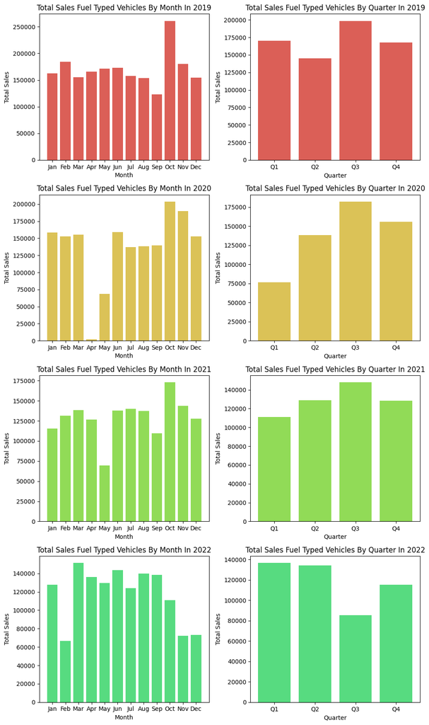

```python
fig , ax = plt.subplots(4, 2, figsize =(10,17))

#colors for plot
color_0 = sns.color_palette('hls', 8)[0]
color_1 = sns.color_palette('hls', 8)[1]
color_2 = sns.color_palette('hls', 8)[2]
color_3 = sns.color_palette('hls', 8)[3]

#Total sales monthly and quarterly in 2019
ax[0,0].bar(pivot_2019_by_month['Mmm'], pivot_2019_by_month['total_sales_fuel_typed'], color = color_0)
ax[0,1].bar(pivot_2019_by_quar['quarter'], pivot_2019_by_quar['total_sales_fuel_typed'], color = color_0)

#Total sales monthly and quarterly in 2020
ax[1,0].bar(pivot_2020_by_month['Mmm'], pivot_2020_by_month['total_sales_fuel_typed'], color = color_1)
ax[1,1].bar(pivot_2020_by_quar['quarter'], pivot_2020_by_quar['total_sales_fuel_typed'], color = color_1)

#Total sales monthly and quarterly in 2021
ax[2,0].bar(pivot_2021_by_month['Mmm'], pivot_2021_by_month['total_sales_fuel_typed'], color = color_2)
ax[2,1].bar(pivot_2021_by_quar['quarter'], pivot_2021_by_quar['total_sales_fuel_typed'], color = color_2)

#Total sales monthly and quarterly in 2022
ax[3,0].bar(pivot_2022_by_month['Mmm'], pivot_2022_by_month['total_sales_fuel_typed'], color = color_3)
ax[3,1].bar(pivot_2022_by_quar['quarter'], pivot_2022_by_quar['total_sales_fuel_typed'], color = color_3)


#Title for plots
#2019
ax[0,0].set_title('Total Sales Fuel Typed Vehicles By Month In 2019')
ax[0,0].set_xlabel('Month')
ax[0,0].set_ylabel('Total Sales')

ax[0,1].set_title('Total Sales Fuel Typed Vehicles By Quarter In 2019')
ax[0,1].set_xlabel('Quarter')
ax[0,1].set_ylabel('Total Sales')

#2020
ax[1,0].set_title('Total Sales Fuel Typed Vehicles By Month In 2020')
ax[1,0].set_xlabel('Month')
ax[1,0].set_ylabel('Total Sales')

ax[1,1].set_title('Total Sales Fuel Typed Vehicles By Quarter In 2020')
ax[1,1].set_xlabel('Quarter')
ax[1,1].set_ylabel('Total Sales')

#2021
ax[2,0].set_title('Total Sales Fuel Typed Vehicles By Month In 2021')
ax[2,0].set_xlabel('Month')
ax[2,0].set_ylabel('Total Sales')

ax[2,1].set_title('Total Sales Fuel Typed Vehicles By Quarter In 2021')
ax[2,1].set_xlabel('Quarter')
ax[2,1].set_ylabel('Total Sales')

#2022
ax[3,0].set_title('Total Sales Fuel Typed Vehicles By Month In 2022')
ax[3,0].set_xlabel('Month')
ax[3,0].set_ylabel('Total Sales')

ax[3,1].set_title('Total Sales Fuel Typed Vehicles By Quarter In 2022')
ax[3,1].set_xlabel('Quarter')
ax[3,1].set_ylabel('Total Sales')


plt.tight_layout()
plt.show()
```

- Visualizing total sales Fuel-Typed yearly:

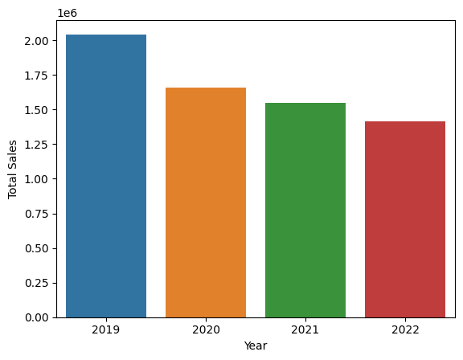

```python
sns.barplot(x = grouped_by_yearly['fiscal_year'], y = grouped_by_yearly['total_sales_fuel_typed'])
plt.xlabel('Year')
plt.ylabel('Total Sales')
plt.show()
```

**Monthly Sales:**

- In 2019, the highest sales were observed in October (261,064) and the lowest in September (123,221).
- In 2020, the highest sales were observed in October (203,828) and the lowest in April (1,994).
- In 2021, the highest sales were observed in October (173,020) and the lowest in May (69,465).
- In 2022, the highest sales were observed in March (151,416) and the lowest in February (66,431).

**Quarterly Sales:**

- The total sales of fuel-typed vehicles decreased each year from 2019 to 2022.

As for the driving factors behind these trends:

1. **Seasonal Factors**: Vehicle sales often increase during festive seasons or when new models are launched.
2. **Economic Factors**: The state of the economy can greatly influence vehicle sales. For instance, a strong economy will encourage consumers to purchase new vehicles.
3. **Policy Changes**: Government policies such as changes in tax rates or introduction of new regulations can also impact vehicle sales.

To increase vehicle sales, it would be beneficial for the government to introduce incentives during low-sales periods. Additionally, promoting fuel-efficient vehicles could attract environmentally conscious consumers.

**6 . How does the distribution of vehicles vary by vehicle class (MotorCycle, MotorCar, AutoRickshaw, Agriculture) across different districts? Are there any districts with a predominant preference for a specific vehicle class? Consider FY 2022 for analysis.**

```python
transport_2022 = transport_df[transport_df['fiscal_year'] == 2022]
vehicle_class = ['vehicleClass_MotorCycle', 'vehicleClass_MotorCar', 'vehicleClass_AutoRickshaw', 'vehicleClass_Agriculture']
district_vehicle_df = transport_2022.groupby('district')[vehicle_class].sum()
district_vehicle_df['predominant_vehicle_class'] = district_vehicle_df.idxmax(axis=1)
district_vehicle_df
```

| district | vehicleClass_MotorCycle | vehicleClass_MotorCar | vehicleClass_AutoRickshaw | vehicleClass_Agriculture | predominant_vehicle_class |
| --- | --- | --- | --- | --- | --- |
| Adilabad | 10410 | 1416 | 368 | 467 | vehicleClass_MotorCycle |
| Bhadradri Kothagudem | 17022 | 3157 | 1388 | 2013 | vehicleClass_MotorCycle |
| Hyderabad | 206819 | 51447 | 8397 | 20 | vehicleClass_MotorCycle |
| Jagtial | 13639 | 2055 | 272 | 858 | vehicleClass_MotorCycle |
| Jangoan | 8617 | 1177 | 397 | 1225 | vehicleClass_MotorCycle |
| Jayashankar Bhupalpally | 9225 | 1343 | 218 | 1928 | vehicleClass_MotorCycle |
| Jogulamba Gadwal | 10300 | 899 | 116 | 868 | vehicleClass_MotorCycle |
| Kamareddy | 15184 | 2153 | 379 | 748 | vehicleClass_MotorCycle |
| Karimnagar | 19411 | 4818 | 1042 | 999 | vehicleClass_MotorCycle |
| Khammam | 27385 | 5880 | 2690 | 2121 | vehicleClass_MotorCycle |
| Kumurambheem Asifabad | 6433 | 479 | 286 | 160 | vehicleClass_MotorCycle |
| Mahabubabad | 11046 | 1155 | 680 | 906 | vehicleClass_MotorCycle |
| Mahabubnagar | 17977 | 3300 | 1130 | 937 | vehicleClass_MotorCycle |
| Mancherial | 11603 | 2218 | 550 | 400 | vehicleClass_MotorCycle |
| Medak | 11663 | 2347 | 610 | 1579 | vehicleClass_MotorCycle |
| Medchal_Malkajgiri | 164626 | 61071 | 83 | 261 | vehicleClass_MotorCycle |
| Nagarkurnool | 12229 | 2066 | 366 | 1556 | vehicleClass_MotorCycle |
| Nalgonda | 27942 | 4927 | 964 | 2599 | vehicleClass_MotorCycle |
| Nirmal | 10984 | 1581 | 295 | 989 | vehicleClass_MotorCycle |
| Nizamabad | 28105 | 5824 | 1011 | 1181 | vehicleClass_MotorCycle |
| Peddapalli | 10818 | 2205 | 382 | 705 | vehicleClass_MotorCycle |
| Rajanna Sircilla | 8007 | 1376 | 148 | 675 | vehicleClass_MotorCycle |
| Rangareddy | 154186 | 71832 | 69 | 449 | vehicleClass_MotorCycle |
| Sangareddy | 40784 | 14565 | 3381 | 1570 | vehicleClass_MotorCycle |
| Siddipet | 17401 | 3254 | 524 | 2437 | vehicleClass_MotorCycle |
| Suryapet | 19165 | 3038 | 739 | 2188 | vehicleClass_MotorCycle |
| Vikarabad | 23116 | 5211 | 2046 | 1814 | vehicleClass_MotorCycle |
| Wanaparthy | 8771 | 1194 | 372 | 985 | vehicleClass_MotorCycle |
| Warangal | 17770 | 2937 | 1331 | 681 | vehicleClass_MotorCycle |
| Yadadri Bhuvanagiri | 14471 | 3216 | 465 | 1853 | vehicleClass_MotorCycle |

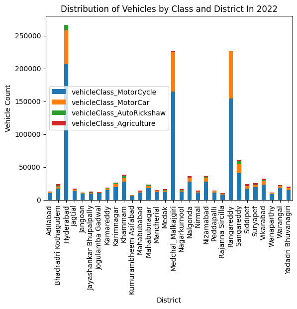

```python
district_vehicle_df.plot(kind='bar', stacked=True)
plt.title('Distribution of Vehicles by Class and District In 2022')
plt.xlabel('District')
plt.ylabel('Vehicle Count')
plt.show()
```

From this analysis, it's clear that the MotorCycle class is the most preferred vehicle class across all districts. However, the preference for other vehicle classes like MotorCar, AutoRickshaw, and Agriculture varies from district to district. Factors influencing these preferences could include the district's economic status, road infrastructure, and local needs or customs.

**7. List down the top 3 and bottom 3 districts that have shown the highest and lowest vehicle sales growth during FY 2022 compared to FY 2021? (Consider and compare categories: Petrol, Diesel and Electric)**

```python
fuel_type_cols = ['fuel_type_petrol','fuel_type_diesel', 'fuel_type_electric']
sales_2021 = transport_df[transport_df['fiscal_year'] == 2021].groupby('district')[fuel_type_cols].sum()
sales_2021['total_sales'] = (
    sales_2021['fuel_type_petrol'] +
    sales_2021['fuel_type_diesel'] +
    sales_2021['fuel_type_electric'] )
```

```python
sales_2022 = transport_df[transport_df['fiscal_year'] == 2022].groupby('district')[fuel_type_cols].sum()
sales_2022['total_sales'] = (
    sales_2022['fuel_type_petrol'] +
    sales_2022['fuel_type_diesel'] +
    sales_2022['fuel_type_electric'] )
```

```python
sales_growth = (sales_2022 - sales_2021)/sales_2021
sales_growth
```

| district | fuel_type_petrol | fuel_type_diesel | fuel_type_electric | total_sales |
| --- | --- | --- | --- | --- |
| Adilabad | -0.324253 | 0.112925 | 0.202166 | -0.264841 |
| Bhadradri Kothagudem | -0.300868 | -0.004705 | 2.815789 | -0.243000 |
| Hyderabad | 0.010266 | -0.055485 | 1.242804 | 0.047385 |
| Jagtial | -0.405252 | -0.212744 | 0.569682 | -0.371537 |
| Jangoan | -0.312288 | -0.219968 | 1.452055 | -0.287681 |
| Jayashankar Bhupalpally | -0.349253 | -0.188268 | 1.045045 | -0.309701 |
| Jogulamba Gadwal | -0.233724 | 0.011693 | 0.615385 | -0.196928 |
| Kamareddy | -0.345884 | 0.074642 | 0.491803 | -0.297479 |
| Karimnagar | -0.154777 | 1.114422 | 0.607955 | 0.044180 |
| Khammam | -0.258599 | -0.003475 | 4.093960 | -0.204871 |
| Kumurambheem Asifabad | -0.329608 | -0.060523 | 1.382353 | -0.283556 |
| Mahabubabad | -0.360821 | -0.242895 | 1.805556 | -0.336049 |
| Mahabubnagar | -0.353178 | -0.205507 | 0.194444 | -0.324853 |
| Mancherial | -0.294770 | -0.092593 | 0.191919 | -0.261468 |
| Medak | -0.274055 | -0.068753 | 0.724324 | -0.226472 |
| Medchal_Malkajgiri | -0.009042 | 0.016168 | 0.935648 | 0.022199 |
| Nagarkurnool | -0.260474 | -0.133635 | 0.628571 | -0.226863 |
| Nalgonda | -0.234440 | -0.148936 | 0.405063 | -0.213982 |
| Nirmal | -0.410514 | -0.014160 | 0.892958 | -0.344545 |
| Nizamabad | -0.342295 | -0.066632 | 0.240524 | -0.298083 |
| Peddapalli | -0.311325 | -0.212873 | 0.844749 | -0.284687 |
| Rajanna Sircilla | -0.388045 | -0.119423 | 0.149171 | -0.341179 |
| Rangareddy | 0.087322 | 0.126745 | 1.299088 | 0.125237 |
| Sangareddy | -0.076069 | 0.132064 | 0.950578 | -0.023889 |
| Siddipet | -0.295256 | -0.086597 | 0.737079 | -0.247028 |
| Suryapet | -0.253223 | -0.089589 | 2.471503 | -0.202778 |
| Vikarabad | -0.277004 | -0.045884 | 0.464752 | -0.236598 |
| Wanaparthy | -0.290268 | 0.021966 | 0.054795 | -0.236111 |
| Warangal | -0.453198 | -0.480322 | 0.548926 | -0.446918 |
| Yadadri Bhuvanagiri | -0.239242 | -0.014965 | 0.209607 | -0.195586 |

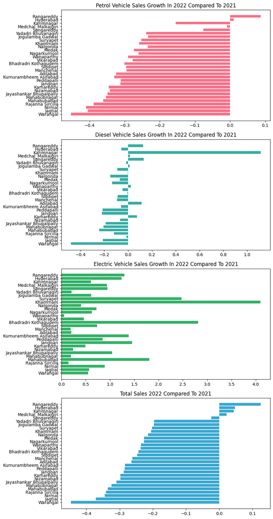

```python
sales_growth_2022 = sales_growth.sort_values('total_sales', ascending = True)

fig, ax = plt.subplots(4, 1, figsize=(9, 17))

#Colors
color_0 = sns.color_palette('husl', 8)
color_1 = sns.color_palette('husl', 8)
color_2 = sns.color_palette('husl', 8)

#Plots
ax[0].barh(sales_growth_2022.index, sales_growth_2022['fuel_type_petrol'], color = color_0[0])
ax[1].barh(sales_growth_2022.index, sales_growth_2022['fuel_type_diesel'], color = color_1[4])
ax[2].barh(sales_growth_2022.index, sales_growth_2022['fuel_type_electric'], color = color_2[3])
ax[3].barh(sales_growth_2022.index, sales_growth_2022['total_sales'], color = color_2[5])

#Title for plots
ax[0].set_title('Petrol Vehicle Sales Growth In 2022 Compared To 2021')
ax[1].set_title('Diesel Vehicle Sales Growth In 2022 Compared To 2021')
ax[2].set_title('Electric Vehicle Sales Growth In 2022 Compared To 2021')
ax[3].set_title('Total Sales 2022 Compared To 2021')

plt.tight_layout()
plt.show()
```

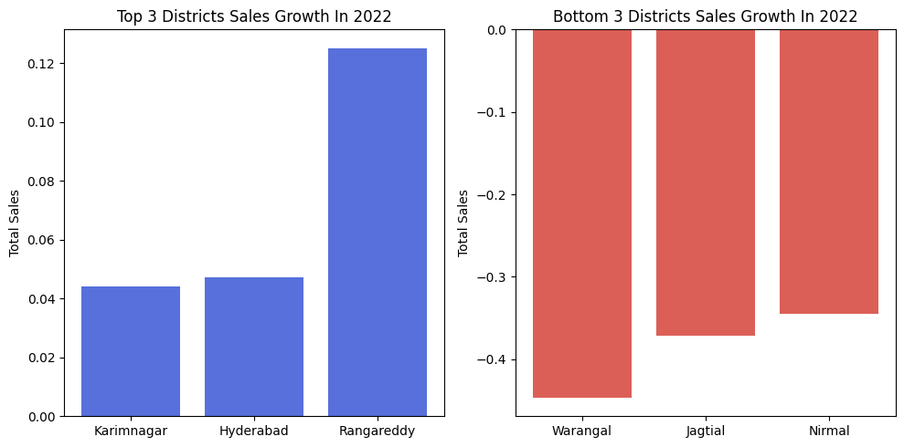

```python
top_3_districts = sales_growth_2022.tail(3)
bottom_3_districts = sales_growth_2022.head(3)

fig, ax = plt.subplots(1, 2, figsize=(10, 5))
color_0 = sns.color_palette('hls', 8)[0]
color_1 = sns.color_palette('hls', 8)[5]
# Plot data for top 3 districts
ax[0].bar(top_3_districts.index, top_3_districts['total_sales'], color = color_1)
ax[0].set_title('Top 3 Districts Sales Growth In 2022')
ax[0].set_ylabel('Total Sales')

# Plot data for bottom 3 districts
ax[1].bar( bottom_3_districts.index, bottom_3_districts['total_sales'], color = color_0)
ax[1].set_title('Bottom 3 Districts Sales Growth In 2022')
ax[1].set_ylabel('Total Sales')

plt.tight_layout()
plt.show()
```

**Bottom 3 Districts (Lowest Growth)**

1. **Warangal**: The total sales growth was approximately **-44.69%**. The growth in petrol, diesel, and electric vehicles was about **-45.32%**, **-48.03%**, and **54.89%** respectively.
2. **Jagtial**: The total sales growth was approximately **-37.15%**. The growth in petrol, diesel, and electric vehicles was about **-40.53%**, **-21.27%**, and **56.97%** respectively.
3. **Nirmal**: The total sales growth was approximately **-34.45%**. The growth in petrol, diesel, and electric vehicles was about **-41.05%**, **-1.42%**, and **89.30%** respectively.

These figures indicate that while some districts have seen significant growth in vehicle sales, others have experienced a decline during FY 2022 compared to FY 2021.

### Ts-Ipass (Telangana State Industrial Project Approval and Self Certification System)

**8. List down the top 5 sectors that have witnessed the most significant investments in FY 2022.**

```python
ts_ipass_fy_2022 = ts_ipass_df[ts_ipass_df['fiscal_year'] == 2022]
```

```python
sector_invest_2022 = ts_ipass_fy_2022.groupby('sector')['investment in cr'].sum()
top_5_sector_invest_2022 = sector_invest_2022.sort_values(ascending = False).head(5)
top_5_sector_invest_2022 = top_5_sector_invest_2022.reset_index()
top_5_sector_invest_2022
```

|  | sector | investment in cr |
| --- | --- | --- |
| 0 | Plastic and Rubber | 5855.6095 |
| 1 | Pharmaceuticals and Chemicals | 2181.6342 |
| 2 | Real Estate,Industrial Parks and IT Buildings | 2127.2963 |
| 3 | Solar and Other Renewable Energy | 2052.9850 |
| 4 | Engineering | 1877.4533 |

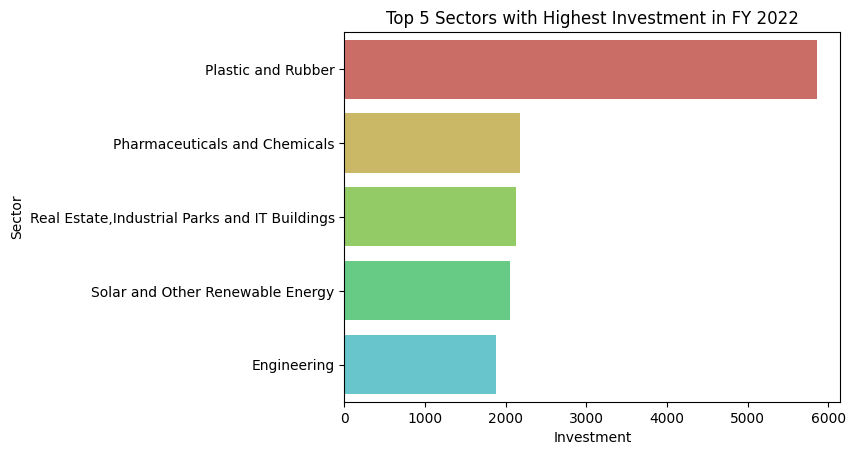

```python
colors = sns.color_palette('hls', 8)
sns.barplot(x = top_5_sector_invest_2022['investment in cr'], y = top_5_sector_invest_2022['sector'], orient = 'h', palette = colors)
plt.title('Top 5 Sectors with Highest Investment in FY 2022')
plt.xlabel('Investment')
plt.ylabel('Sector')
plt.show()
```

The top 5 sectors that have witnessed the most significant investments in FY 2022 are:

1. **Plastic and Rubber**: 5855.6095 cr
2. **Pharmaceuticals and Chemicals**: 2181.6342 cr
3. **Real Estate, Industrial Parks and IT Buildings**: 2127.2963 cr
4. **Solar and Other Renewable Energy**: 2052.9850 cr
5. **Engineering**: 1877.4533 cr

These sectors have attracted the highest investments, indicating strong growth and development potential.

**9. List down the top 3 districts that have attracted the most significant sector investments during FY 2019 to 2022? What factors could have led to the substantial investments in these particular districts?**

```python
distric_invest_2019_2022 = ts_ipass_df.groupby('district')['investment in cr'].sum()
top_3_distric_invest_2019_2022 = distric_invest_2019_2022.sort_values(ascending = False).head(3)
top_3_distric_invest_2019_2022 = top_3_distric_invest_2019_2022.reset_index()
top_3_distric_invest_2019_2022
```

|  | district | investment in cr |
| --- | --- | --- |
| 0 | Rangareddy | 42706.3320 |
| 1 | Sangareddy | 12366.7556 |
| 2 | Medchal_Malkajgiri | 10394.5610 |

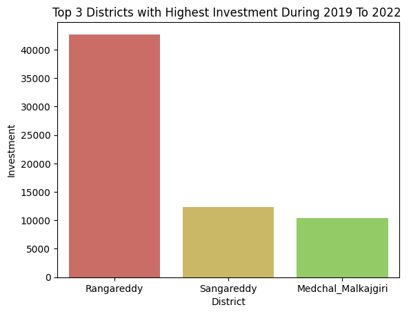

```python
colors = sns.color_palette('hls', 8)
sns.barplot(x = top_3_distric_invest_2019_2022['district'], y = top_3_distric_invest_2019_2022['investment in cr'], palette = colors)
plt.title('Top 3 Districts with Highest Investment During 2019 To 2022 ')
plt.xlabel('District')
plt.ylabel('Investment')
plt.show()
```

Factors could have led to substantial investments in these particular districts, it could be a variety of factors such as:

- **Infrastructure**: Districts with better infrastructure such as roads, ports, airports, and utilities often attract more investment.
- **Government Policies**: Favorable government policies such as tax incentives, subsidies, and ease of doing business can also attract investment.
- **Availability of Skilled Labor**: Districts with a large pool of skilled labor can attract industries that require such skills.
- **Market Access**: Districts that are close to major markets or have good connectivity to them can attract more investment.

**10. Is there any relationship between district investments, vehicles sales and stamps revenue within the same district between FY 2021 and 2022?**

```python
stamps_df_2021_2022 = stamps_df[stamps_df['fiscal_year'].isin([2021,2022])]
transport_df_2021_2022 = transport_df[transport_df['fiscal_year'].isin([2021,2022])]
ts_ipass_df_2021_2022 = ts_ipass_df[ts_ipass_df['fiscal_year'].isin([2021,2022])]
```

```python
transport_df_2021_2022['total_vehicle_sales'] = transport_df_2021_2022[['fuel_type_petrol', 'fuel_type_diesel', 'fuel_type_electric', 'fuel_type_others', 'vehicleClass_MotorCycle', 'vehicleClass_MotorCar', 'vehicleClass_AutoRickshaw', 'vehicleClass_Agriculture', 'vehicleClass_others']].sum(axis=1)
```

```python
#District investment
invest_by_dist = ts_ipass_df_2021_2022.groupby('district')['investment in cr'].sum()

#Vehicle Sales
total_vehicle_sales_by_dist = transport_df_2021_2022.groupby('district')['total_vehicle_sales'].sum()

#stamps revenue and document revenue
document_rev = stamps_df_2021_2022.groupby('district')['documents_registered_rev'].sum()
estamps_rev = stamps_df_2021_2022.groupby('district')['estamps_challans_rev'].sum()
```

```python
# Combine the Series into a DataFrame
combined_df = pd.concat([invest_by_dist, total_vehicle_sales_by_dist, document_rev, estamps_rev], axis=1)

# Rename the columns
combined_df.columns = ['investment', 'total_vehicle_sales', 'documents_registered_rev', 'estamps_challans_rev']
```

```python
combined_df.info()
```

```
<class 'pandas.core.frame.DataFrame'>
Index: 33 entries, Adilabad to Yadadri Bhuvanagiri
Data columns (total 4 columns):
 #   Column                    Non-Null Count  Dtype
---  ------                    --------------  -----
 0   investment                33 non-null     float64
 1   total_vehicle_sales       30 non-null     float64
 2   documents_registered_rev  32 non-null     float64
 3   estamps_challans_rev      32 non-null     float64
dtypes: float64(4)
memory usage: 1.3+ KB
```

```python
combined_df.isna().sum()
```

```
investment                  0
total_vehicle_sales         3
documents_registered_rev    1
estamps_challans_rev        1
dtype: int64
```

```python
combined_df = combined_df.fillna(combined_df.mean())
```

```python
combined_df.isna().sum()
```

```
investment                  0
total_vehicle_sales         0
documents_registered_rev    0
estamps_challans_rev        0
dtype: int64
```

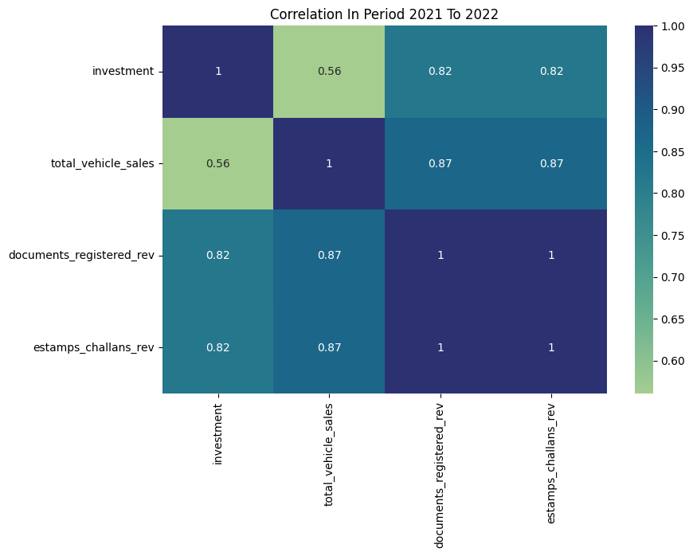

```python
color = sns.color_palette("crest", as_cmap=True)
plt.figure(figsize = (9,6))
sns.heatmap(combined_df.corr(),cmap = color ,annot = True)
plt.title('Correlation In Period 2021 To 2022')
plt.show()
```

**- Investment and Total Vehicle Sales:** The correlation coefficient is approximately 0.56, indicating a moderate positive relationship. This suggests that districts with higher investments tend to have higher vehicle sales.

**- Investment and Documents Registered Revenue:** The correlation coefficient is approximately 0.82, indicating a strong positive relationship. This suggests that districts with higher investments tend to have higher revenue from registered documents.

**- Investment and E-stamp Challans Revenue:** The correlation coefficient is approximately 0.82, indicating a strong positive relationship. This suggests that districts with higher investments tend to have higher revenue from e-stamp challans.

**- Total Vehicle Sales and Documents Registered Revenue:** The correlation coefficient is approximately 0.87, indicating a strong positive relationship. This suggests that districts with higher vehicle sales tend to have higher revenue from registered documents.

**- Total Vehicle Sales and E-stamp Challans Revenue:** The correlation coefficient is approximately 0.87, indicating a strong positive relationship. This suggests that districts with higher vehicle sales tend to have higher revenue from e-stamp challans.

**- Documents Registered Revenue and E-stamp Challans Revenue:** The correlation coefficient is approximately 1.00, indicating a very strong positive relationship. This suggests that districts with higher revenue from registered documents also tend to have higher revenue from e-stamp challans.

**11. Are there any particular sectors that have shown substantial investment in multiple districts between FY 2021 and 2022?**

**Ficsal year 2021:**

```python
ts_ipass_df_2021 = ts_ipass_df[ts_ipass_df['fiscal_year'] == 2021]
sector_by_dist_2021_temp = ts_ipass_df_2021.groupby('sector')['district'].unique()
sector_by_dist_2021_temp = sector_by_dist_2021_temp.reset_index()
sector_by_dist_2021_temp['num_district'] = sector_by_dist_2021_temp['district'].apply(len)
sector_by_dist_2021_temp
```

|  | sector | district | num_district |
| --- | --- | --- | --- |
| 0 | Agro based incl Cold Storages | [Jagtial, Jangoan, Kamareddy, Karimnagar, Kham... | 28 |
| 1 | Automobile | [Nirmal, Rangareddy] | 2 |
| 2 | Beverages | [Adilabad, Jagtial, Jangoan, Khammam, Medak, S... | 21 |
| 3 | Cement, Cement & Concrete Products, Fly Ash Br... | [Adilabad, Bhadradri Kothagudem, Jagtial, Jang... | 28 |
| 4 | Electrical and Electronic Products | [Medak, Medchal_Malkajgiri, Sangareddy, Warang... | 10 |
| 5 | Engineering | [Hyderabad, Jagtial, Karimnagar, Khammam, Manc... | 30 |
| 6 | Fertlizers Organic and Inorganic,Pesticides,In... | [Yadadri Bhuvanagiri, Rangareddy, Medak, Sanga... | 10 |
| 7 | Food Processing | [Jagtial, Jangoan, Jogulamba Gadwal, Kamareddy... | 33 |
| 8 | Granite and Stone Crushing | [Karimnagar, Khammam, Nalgonda, Nizamabad, Raj... | 24 |
| 9 | Others | [Mancherial, Nizamabad, Rangareddy, Sangareddy... | 27 |
| 10 | Paper and Printing | [Medak, Medchal_Malkajgiri, Nagarkurnool, Yada... | 17 |
| 11 | Pharmaceuticals and Chemicals | [Jagtial, Medak, Medchal_Malkajgiri, Rangaredd... | 24 |
| 12 | Plastic and Rubber | [Jogulamba Gadwal, Mancherial, Medchal_Malkajg... | 23 |
| 13 | R&D | [Medchal_Malkajgiri, Sangareddy, Mahabubnagar,... | 6 |
| 14 | Real Estate,Industrial Parks and IT Buildings | [Sangareddy, Rangareddy, Karimnagar] | 3 |
| 15 | Solar and Other Renewable Energy | [Yadadri Bhuvanagiri, Medchal_Malkajgiri, Sang... | 7 |
| 16 | Textiles | [Jogulamba Gadwal, Narayanpet, Rajanna Sircill... | 16 |
| 17 | Wood and Leather | [Jagtial, Kamareddy, Sangareddy, Suryapet, Vik... | 20 |

```python
total_invest_by_sector_2021_temp = ts_ipass_df_2021.groupby('sector')['investment in cr'].sum()
total_invest_by_sector_2021_temp = total_invest_by_sector_2021_temp.reset_index()
total_invest_by_sector_2021_temp
```

|  | sector | investment in cr |
| --- | --- | --- |
| 0 | Agro based incl Cold Storages | 325.2291 |
| 1 | Automobile | 5.0000 |
| 2 | Beverages | 1843.6802 |
| 3 | Cement, Cement & Concrete Products, Fly Ash Br... | 120.9007 |
| 4 | Electrical and Electronic Products | 176.4594 |
| 5 | Engineering | 967.5172 |
| 6 | Fertlizers Organic and Inorganic,Pesticides,In... | 23.4525 |
| 7 | Food Processing | 999.3621 |
| 8 | Granite and Stone Crushing | 400.7498 |
| 9 | Others | 647.6261 |
| 10 | Paper and Printing | 205.9040 |
| 11 | Pharmaceuticals and Chemicals | 6860.9321 |
| 12 | Plastic and Rubber | 2059.6245 |
| 13 | R&D | 876.7164 |
| 14 | Real Estate,Industrial Parks and IT Buildings | 2015.2619 |
| 15 | Solar and Other Renewable Energy | 164.0238 |
| 16 | Textiles | 162.3720 |
| 17 | Wood and Leather | 34.0320 |

```python
sector_dist_investment_2021 = pd.merge(sector_by_dist_2021_temp, total_invest_by_sector_2021_temp, on = 'sector', how = 'inner')
sector_dist_investment_2021
```

|  | sector | district | num_district | investment in cr |
| --- | --- | --- | --- | --- |
| 0 | Agro based incl Cold Storages | [Jagtial, Jangoan, Kamareddy, Karimnagar, Kham... | 28 | 325.2291 |
| 1 | Automobile | [Nirmal, Rangareddy] | 2 | 5.0000 |
| 2 | Beverages | [Adilabad, Jagtial, Jangoan, Khammam, Medak, S... | 21 | 1843.6802 |
| 3 | Cement, Cement & Concrete Products, Fly Ash Br... | [Adilabad, Bhadradri Kothagudem, Jagtial, Jang... | 28 | 120.9007 |
| 4 | Electrical and Electronic Products | [Medak, Medchal_Malkajgiri, Sangareddy, Warang... | 10 | 176.4594 |
| 5 | Engineering | [Hyderabad, Jagtial, Karimnagar, Khammam, Manc... | 30 | 967.5172 |
| 6 | Fertlizers Organic and Inorganic,Pesticides,In... | [Yadadri Bhuvanagiri, Rangareddy, Medak, Sanga... | 10 | 23.4525 |
| 7 | Food Processing | [Jagtial, Jangoan, Jogulamba Gadwal, Kamareddy... | 33 | 999.3621 |
| 8 | Granite and Stone Crushing | [Karimnagar, Khammam, Nalgonda, Nizamabad, Raj... | 24 | 400.7498 |
| 9 | Others | [Mancherial, Nizamabad, Rangareddy, Sangareddy... | 27 | 647.6261 |
| 10 | Paper and Printing | [Medak, Medchal_Malkajgiri, Nagarkurnool, Yada... | 17 | 205.9040 |
| 11 | Pharmaceuticals and Chemicals | [Jagtial, Medak, Medchal_Malkajgiri, Rangaredd... | 24 | 6860.9321 |
| 12 | Plastic and Rubber | [Jogulamba Gadwal, Mancherial, Medchal_Malkajg... | 23 | 2059.6245 |
| 13 | R&D | [Medchal_Malkajgiri, Sangareddy, Mahabubnagar,... | 6 | 876.7164 |
| 14 | Real Estate,Industrial Parks and IT Buildings | [Sangareddy, Rangareddy, Karimnagar] | 3 | 2015.2619 |
| 15 | Solar and Other Renewable Energy | [Yadadri Bhuvanagiri, Medchal_Malkajgiri, Sang... | 7 | 164.0238 |
| 16 | Textiles | [Jogulamba Gadwal, Narayanpet, Rajanna Sircill... | 16 | 162.3720 |
| 17 | Wood and Leather | [Jagtial, Kamareddy, Sangareddy, Suryapet, Vik... | 20 | 34.0320 |

```python
sector_by_district_2021 = sector_dist_investment_2021.sort_values(by = 'num_district', ascending = True)
top_10_sector_by_district_2021 = sector_by_district_2021.tail(10)
top_10_sector_by_district_2021
```

|  | sector | district | num_district | investment in cr |
| --- | --- | --- | --- | --- |
| 17 | Wood and Leather | [Jagtial, Kamareddy, Sangareddy, Suryapet, Vik... | 20 | 34.0320 |
| 2 | Beverages | [Adilabad, Jagtial, Jangoan, Khammam, Medak, S... | 21 | 1843.6802 |
| 12 | Plastic and Rubber | [Jogulamba Gadwal, Mancherial, Medchal_Malkajg... | 23 | 2059.6245 |
| 8 | Granite and Stone Crushing | [Karimnagar, Khammam, Nalgonda, Nizamabad, Raj... | 24 | 400.7498 |
| 11 | Pharmaceuticals and Chemicals | [Jagtial, Medak, Medchal_Malkajgiri, Rangaredd... | 24 | 6860.9321 |
| 9 | Others | [Mancherial, Nizamabad, Rangareddy, Sangareddy... | 27 | 647.6261 |
| 3 | Cement, Cement & Concrete Products, Fly Ash Br... | [Adilabad, Bhadradri Kothagudem, Jagtial, Jang... | 28 | 120.9007 |
| 0 | Agro based incl Cold Storages | [Jagtial, Jangoan, Kamareddy, Karimnagar, Kham... | 28 | 325.2291 |
| 5 | Engineering | [Hyderabad, Jagtial, Karimnagar, Khammam, Manc... | 30 | 967.5172 |
| 7 | Food Processing | [Jagtial, Jangoan, Jogulamba Gadwal, Kamareddy... | 33 | 999.3621 |

```python
invest_amount_2021 = sector_dist_investment_2021.sort_values(by = 'investment in cr', ascending = True)
top_10_invest_amount_2021 = invest_amount_2021.tail(10)
top_10_invest_amount_2021
```

|  | sector | district | num_district | investment in cr |
| --- | --- | --- | --- | --- |
| 0 | Agro based incl Cold Storages | [Jagtial, Jangoan, Kamareddy, Karimnagar, Kham... | 28 | 325.2291 |
| 8 | Granite and Stone Crushing | [Karimnagar, Khammam, Nalgonda, Nizamabad, Raj... | 24 | 400.7498 |
| 9 | Others | [Mancherial, Nizamabad, Rangareddy, Sangareddy... | 27 | 647.6261 |
| 13 | R&D | [Medchal_Malkajgiri, Sangareddy, Mahabubnagar,... | 6 | 876.7164 |
| 5 | Engineering | [Hyderabad, Jagtial, Karimnagar, Khammam, Manc... | 30 | 967.5172 |
| 7 | Food Processing | [Jagtial, Jangoan, Jogulamba Gadwal, Kamareddy... | 33 | 999.3621 |
| 2 | Beverages | [Adilabad, Jagtial, Jangoan, Khammam, Medak, S... | 21 | 1843.6802 |
| 14 | Real Estate,Industrial Parks and IT Buildings | [Sangareddy, Rangareddy, Karimnagar] | 3 | 2015.2619 |
| 12 | Plastic and Rubber | [Jogulamba Gadwal, Mancherial, Medchal_Malkajg... | 23 | 2059.6245 |
| 11 | Pharmaceuticals and Chemicals | [Jagtial, Medak, Medchal_Malkajgiri, Rangaredd... | 24 | 6860.9321 |

**Fiscal year 2022:**

```python
ts_ipass_df_2022 = ts_ipass_df[ts_ipass_df['fiscal_year'] == 2022]
sector_by_dist_2022_temp = ts_ipass_df_2022.groupby('sector')['district'].unique()
sector_by_dist_2022_temp = sector_by_dist_2022_temp.reset_index()
sector_by_dist_2022_temp['num_district'] = sector_by_dist_2022_temp['district'].apply(len)
sector_by_dist_2022_temp
```

|  | sector | district | num_district |
| --- | --- | --- | --- |
| 0 | Agro based incl Cold Storages | [Jagtial, Kamareddy, Karimnagar, Khammam, Maha... | 25 |
| 1 | Automobile | [Sangareddy, Rangareddy, Medchal_Malkajgiri] | 3 |
| 2 | Beverages | [Bhadradri Kothagudem, Jangoan, Khammam, Mahab... | 24 |
| 3 | Cement, Cement & Concrete Products, Fly Ash Br... | [Hanumakonda, Jangoan, Karimnagar, Khammam, Ku... | 31 |
| 4 | Electrical and Electronic Products | [Medchal_Malkajgiri, Nirmal, Rangareddy, Medak... | 8 |
| 5 | Engineering | [Hanumakonda, Hyderabad, Jagtial, Kamareddy, K... | 27 |
| 6 | Fertlizers Organic and Inorganic,Pesticides,In... | [Hanumakonda, Sangareddy, Yadadri Bhuvanagiri,... | 8 |
| 7 | Food Processing | [Bhadradri Kothagudem, Hanumakonda, Jagtial, J... | 33 |
| 8 | Granite and Stone Crushing | [Bhadradri Kothagudem, Hanumakonda, Kamareddy,... | 21 |
| 9 | Industrial Parks and IT Buildings | [Rangareddy] | 1 |
| 10 | Others | [Jangoan, Karimnagar, Khammam, Mahabubnagar, M... | 29 |
| 11 | Paper and Printing | [Bhadradri Kothagudem, Jagtial, Medchal_Malkaj... | 16 |
| 12 | Pharmaceuticals and Chemicals | [Kamareddy, Mahabubnagar, Medak, Medchal_Malka... | 18 |
| 13 | Plastic and Rubber | [Karimnagar, Medak, Medchal_Malkajgiri, Nalgon... | 18 |
| 14 | R&D | [Medchal_Malkajgiri, Sangareddy, Siddipet, Yad... | 8 |
| 15 | Real Estate,Industrial Parks and IT Buildings | [Karimnagar, Rangareddy, Yadadri Bhuvanagiri] | 3 |
| 16 | Solar and Other Renewable Energy | [Jogulamba Gadwal, Mahabubnagar, Medak, Nirmal... | 11 |
| 17 | Textiles | [Jangoan, Mancherial, Rajanna Sircilla, Hanuma... | 17 |
| 18 | Wood and Leather | [Mahabubabad, Siddipet, Karimnagar, Medchal_Ma... | 19 |

```python
total_invest_by_sector_2022_temp = ts_ipass_df_2022.groupby('sector')['investment in cr'].sum()
total_invest_by_sector_2022_temp = total_invest_by_sector_2022_temp.reset_index()
total_invest_by_sector_2022_temp
```

|  | sector | investment in cr |
| --- | --- | --- |
| 0 | Agro based incl Cold Storages | 1263.5502 |
| 1 | Automobile | 1567.4271 |
| 2 | Beverages | 476.7425 |
| 3 | Cement, Cement & Concrete Products, Fly Ash Br... | 1142.7468 |
| 4 | Electrical and Electronic Products | 484.4655 |
| 5 | Engineering | 1877.4533 |
| 6 | Fertlizers Organic and Inorganic,Pesticides,In... | 34.2244 |
| 7 | Food Processing | 1455.9435 |
| 8 | Granite and Stone Crushing | 946.7192 |
| 9 | Industrial Parks and IT Buildings | 280.4090 |
| 10 | Others | 1040.3561 |
| 11 | Paper and Printing | 1251.3714 |
| 12 | Pharmaceuticals and Chemicals | 2181.6342 |
| 13 | Plastic and Rubber | 5855.6095 |
| 14 | R&D | 1484.9027 |
| 15 | Real Estate,Industrial Parks and IT Buildings | 2127.2963 |
| 16 | Solar and Other Renewable Energy | 2052.9850 |
| 17 | Textiles | 176.1469 |
| 18 | Wood and Leather | 63.9763 |

```python
sector_dist_investment_2022 = pd.merge(sector_by_dist_2022_temp, total_invest_by_sector_2022_temp, on = 'sector', how = 'inner')
sector_dist_investment_2022
```

|  | sector | district | num_district | investment in cr |
| --- | --- | --- | --- | --- |
| 0 | Agro based incl Cold Storages | [Jagtial, Kamareddy, Karimnagar, Khammam, Maha... | 25 | 1263.5502 |
| 1 | Automobile | [Sangareddy, Rangareddy, Medchal_Malkajgiri] | 3 | 1567.4271 |
| 2 | Beverages | [Bhadradri Kothagudem, Jangoan, Khammam, Mahab... | 24 | 476.7425 |
| 3 | Cement, Cement & Concrete Products, Fly Ash Br... | [Hanumakonda, Jangoan, Karimnagar, Khammam, Ku... | 31 | 1142.7468 |
| 4 | Electrical and Electronic Products | [Medchal_Malkajgiri, Nirmal, Rangareddy, Medak... | 8 | 484.4655 |
| 5 | Engineering | [Hanumakonda, Hyderabad, Jagtial, Kamareddy, K... | 27 | 1877.4533 |
| 6 | Fertlizers Organic and Inorganic,Pesticides,In... | [Hanumakonda, Sangareddy, Yadadri Bhuvanagiri,... | 8 | 34.2244 |
| 7 | Food Processing | [Bhadradri Kothagudem, Hanumakonda, Jagtial, J... | 33 | 1455.9435 |
| 8 | Granite and Stone Crushing | [Bhadradri Kothagudem, Hanumakonda, Kamareddy,... | 21 | 946.7192 |
| 9 | Industrial Parks and IT Buildings | [Rangareddy] | 1 | 280.4090 |
| 10 | Others | [Jangoan, Karimnagar, Khammam, Mahabubnagar, M... | 29 | 1040.3561 |
| 11 | Paper and Printing | [Bhadradri Kothagudem, Jagtial, Medchal_Malkaj... | 16 | 1251.3714 |
| 12 | Pharmaceuticals and Chemicals | [Kamareddy, Mahabubnagar, Medak, Medchal_Malka... | 18 | 2181.6342 |
| 13 | Plastic and Rubber | [Karimnagar, Medak, Medchal_Malkajgiri, Nalgon... | 18 | 5855.6095 |
| 14 | R&D | [Medchal_Malkajgiri, Sangareddy, Siddipet, Yad... | 8 | 1484.9027 |
| 15 | Real Estate,Industrial Parks and IT Buildings | [Karimnagar, Rangareddy, Yadadri Bhuvanagiri] | 3 | 2127.2963 |
| 16 | Solar and Other Renewable Energy | [Jogulamba Gadwal, Mahabubnagar, Medak, Nirmal... | 11 | 2052.9850 |
| 17 | Textiles | [Jangoan, Mancherial, Rajanna Sircilla, Hanuma... | 17 | 176.1469 |
| 18 | Wood and Leather | [Mahabubabad, Siddipet, Karimnagar, Medchal_Ma... | 19 | 63.9763 |

```python
sector_by_district_2022 = sector_dist_investment_2022.sort_values(by = 'num_district', ascending = True)
top_10_sector_by_district_2022 = sector_by_district_2022.tail(10)
top_10_sector_by_district_2022
```

|  | sector | district | num_district | investment in cr |
| --- | --- | --- | --- | --- |
| 13 | Plastic and Rubber | [Karimnagar, Medak, Medchal_Malkajgiri, Nalgon... | 18 | 5855.6095 |
| 12 | Pharmaceuticals and Chemicals | [Kamareddy, Mahabubnagar, Medak, Medchal_Malka... | 18 | 2181.6342 |
| 18 | Wood and Leather | [Mahabubabad, Siddipet, Karimnagar, Medchal_Ma... | 19 | 63.9763 |
| 8 | Granite and Stone Crushing | [Bhadradri Kothagudem, Hanumakonda, Kamareddy,... | 21 | 946.7192 |
| 2 | Beverages | [Bhadradri Kothagudem, Jangoan, Khammam, Mahab... | 24 | 476.7425 |
| 0 | Agro based incl Cold Storages | [Jagtial, Kamareddy, Karimnagar, Khammam, Maha... | 25 | 1263.5502 |
| 5 | Engineering | [Hanumakonda, Hyderabad, Jagtial, Kamareddy, K... | 27 | 1877.4533 |
| 10 | Others | [Jangoan, Karimnagar, Khammam, Mahabubnagar, M... | 29 | 1040.3561 |
| 3 | Cement, Cement & Concrete Products, Fly Ash Br... | [Hanumakonda, Jangoan, Karimnagar, Khammam, Ku... | 31 | 1142.7468 |
| 7 | Food Processing | [Bhadradri Kothagudem, Hanumakonda, Jagtial, J... | 33 | 1455.9435 |

```python
invest_amount_2022 = sector_dist_investment_2022.sort_values(by = 'investment in cr', ascending = True)
top_10_invest_amount_2022 = invest_amount_2022.tail(10)
top_10_invest_amount_2022
```

|  | sector | district | num_district | investment in cr |
| --- | --- | --- | --- | --- |
| 11 | Paper and Printing | [Bhadradri Kothagudem, Jagtial, Medchal_Malkaj... | 16 | 1251.3714 |
| 0 | Agro based incl Cold Storages | [Jagtial, Kamareddy, Karimnagar, Khammam, Maha... | 25 | 1263.5502 |
| 7 | Food Processing | [Bhadradri Kothagudem, Hanumakonda, Jagtial, J... | 33 | 1455.9435 |
| 14 | R&D | [Medchal_Malkajgiri, Sangareddy, Siddipet, Yad... | 8 | 1484.9027 |
| 1 | Automobile | [Sangareddy, Rangareddy, Medchal_Malkajgiri] | 3 | 1567.4271 |
| 5 | Engineering | [Hanumakonda, Hyderabad, Jagtial, Kamareddy, K... | 27 | 1877.4533 |
| 16 | Solar and Other Renewable Energy | [Jogulamba Gadwal, Mahabubnagar, Medak, Nirmal... | 11 | 2052.9850 |
| 15 | Real Estate,Industrial Parks and IT Buildings | [Karimnagar, Rangareddy, Yadadri Bhuvanagiri] | 3 | 2127.2963 |
| 12 | Pharmaceuticals and Chemicals | [Kamareddy, Mahabubnagar, Medak, Medchal_Malka... | 18 | 2181.6342 |
| 13 | Plastic and Rubber | [Karimnagar, Medak, Medchal_Malkajgiri, Nalgon... | 18 | 5855.6095 |

**Visualize Sectors have invested in a number of districts, and the total investment by each sector for fiscal years 2021 and 2022**

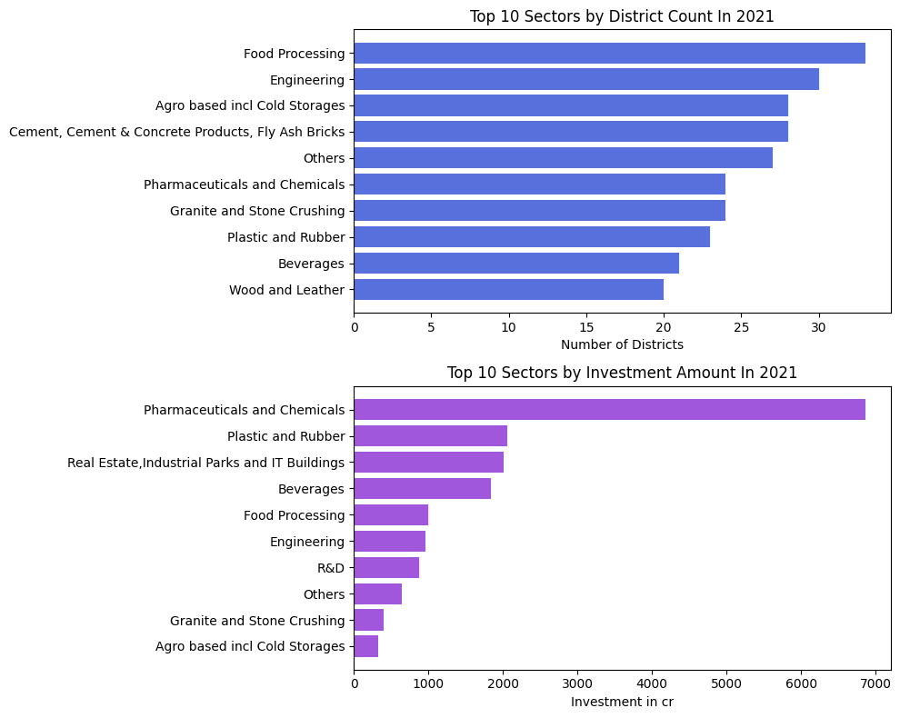

```python
fig, ax = plt.subplots(2,figsize = (10,8))

colors = sns.color_palette('hls', 8)

ax[0].barh(top_10_sector_by_district_2021['sector'], top_10_sector_by_district_2021['num_district'], color= colors[5])
ax[0].set_xlabel('Number of Districts')
ax[0].set_title('Top 10 Sectors by District Count In 2021')


ax[1].barh(top_10_invest_amount_2021['sector'], top_10_invest_amount_2021['investment in cr'], color=colors[6])
ax[1].set_xlabel('Investment in cr')
ax[1].set_title('Top 10 Sectors by Investment Amount In 2021')


plt.tight_layout()
plt.show()
```

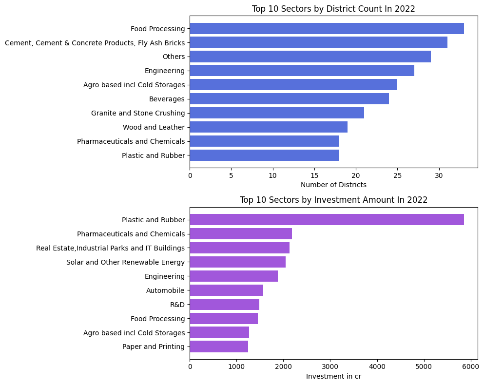

```python
fig, ax = plt.subplots(2,figsize = (10,8))

colors = sns.color_palette('hls', 8)

ax[0].barh(top_10_sector_by_district_2022['sector'], top_10_sector_by_district_2022['num_district'], color= colors[5])
ax[0].set_xlabel('Number of Districts')
ax[0].set_title('Top 10 Sectors by District Count In 2022')


ax[1].barh(top_10_invest_amount_2022['sector'], top_10_invest_amount_2022['investment in cr'], color=colors[6])
ax[1].set_xlabel('Investment in cr')
ax[1].set_title('Top 10 Sectors by Investment Amount In 2022')


plt.tight_layout()
plt.show()
```

These trends indicate a dynamic shift in the sectors that are attracting investments year over year, with some sectors consistently performing well, while others are emerging as new areas of interest.

**12. Can we identify any seasonal patterns or cyclicality in the investment trends for specific sectors? Do certain sectors experience higher investments during particular months?**

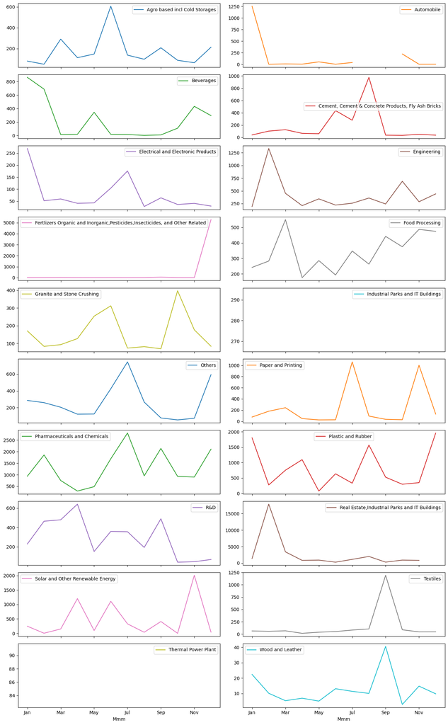

```python
months = ['Jan', 'Feb', 'Mar', 'Apr', 'May', 'Jun', 'Jul', 'Aug', 'Sep', 'Oct', 'Nov', 'Dec']

grouped = ts_ipass_df.groupby(['sector', 'Mmm'])['investment in cr'].sum().reset_index()
grouped['Mmm'] = pd.Categorical(grouped['Mmm'], categories=months, ordered=True)

pivot_df = grouped.pivot(index='Mmm', columns='sector', values='investment in cr')


pivot_df.plot(subplots=True, layout=(-1, 2), figsize=(14, 22))
plt.tight_layout()
plt.show()
```

**Thank you for reading my project**

**Author: Bao Thai**\

Linkedin: https://www.linkedin.com/in/bao-quoc-508008181/ \ Gmail: QuocBao363@gmail.com